# MY459-30499

```
## Package version: 3.2.0
## Unicode version: 10.0
## ICU version: 61.1
```

```
## Parallel computing: 8 of 8 threads used.
```

```
## See https://quanteda.io for tutorials and examples.
```

# Create the sample

```r
sarc <- read.csv("train-balanced-sarcasm.csv")
```

```r
set.seed(123)

nrow(sarc)
```

```
## [1] 1010826
```

```r
#Split the dataset into the sarcastic and non-sarcastic comments. I will process them separetely and then merge them , so that I create at the end a balanced dataset
sarc1<- sarc[sarc$label ==1, ]
sarc0<- sarc[sarc$label ==0, ]
nrow(sarc1)
```

```
## [1] 505413
```

```r
nrow(sarc0)
```

```
## [1] 505413
```

```r
#Draw 2000 random numbers to use tham as indexes in order to select a random sample from the big dataset
sample1_indices <- sample(1:nrow(sarc1), 2000)
sample0_indices <- sample(1:nrow(sarc0), 2000)

#Get a sample for sarcastic and non-sarcastic records equivalently
sarc1<- sarc1[sample1_indices,]
sarc0<- sarc0[sample0_indices,]

#Combine the sarcastic and non-sarcastic records
sarc_df<- rbind(sarc1, sarc0)

#Shuffle the data frame so that sarcastic and non-sarcastic comments are randomly stored
shuffle_ind<- sample(1:4000, 4000)
sarc_df<- sarc_df[shuffle_ind,]

#set the row names to be sequential numbers from 1 to 4000
rownames(sarc_df)<- 1:4000
head(sarc_df)
```

```
##   label
## 1     1
## 2     0
## 3     0
## 4     0
## 5     1
## 6     0
##                                                                                                                                comment
## 1 Lack of acknowledgment of the systematic racism, transphobia, sexism, and [insert identitarian slogan here] endemic to free markets.
## 2                                                                                                    oh the old reddit switche.... NO!
## 3                                                            I don't think anyone else would realize you vomited in your sleep either.
## 4                                                                                                                                  404
## 5                                                                                                                          Money $pent
## 6                  In graphics options there's a checkbox 'run in window' that's windowed mode but it is not borderless or fullscreen.
##                author       subreddit score ups downs    date
```

[output cut: 20 more lines]

```r
#Remove null records
test1<- na.omit(sarc_df)
nrow(test1)
```

```
## [1] 4000
```

```r
#There are no null values
```

# Create the corpus and any document feture matrix that will be needed for the analysis further on:

```r
table(sarc_df$label) #it is a balanced dataset
```

```
##
##    0    1
## 2000 2000
```

```r
#Add label as a factor:
sarc_df$label_f <- factor(sarc_df$label)

#Create a corpus where each comment is a document and add the rest of the variables, except the parent comment, as document variables
sarc_corpus <- corpus(sarc_df$comment, docvars=sarc_df[,3:9])
docvars(sarc_corpus)$label <-sarc_df$label
docvars(sarc_corpus)$label_f <-sarc_df$label_f

#Create 2 different corpora based on whether the comments were or were not sarcastic
sarc_corpus_0<- sarc_corpus[docvars(sarc_corpus)$label==0]
sarc_corpus_1<- sarc_corpus[docvars(sarc_corpus)$label==1]

#Create tokens of words for the comments
#what="word", remove_punct = FALSE are the defaults
sarc_word_toks_0<- tokens(sarc_corpus_0)
sarc_word_toks_1<- tokens(sarc_corpus_1)
```

```r
#With punctuation
#Create dfm for each class, with stopwords and other features removed:
toks_filtered_punct_0 <- sarc_corpus_0 %>%
      tokens(remove_numbers = TRUE, remove_url= TRUE, remove_symbols = TRUE) %>%
      tokens_remove(stopwords("en")) %>%
      tokens_wordstem()
dfm_0_punct_noprop <- toks_filtered_punct_0 %>%
            dfm() %>%
            dfm_trim(min_docfreq = 3)
dfm_punct_0<- dfm_weight(dfm_0_punct_noprop,scheme = "prop")


toks_filtered_punct_1 <- sarc_corpus_1 %>%
      tokens(remove_numbers = TRUE, remove_url= TRUE, remove_symbols = TRUE) %>%
      tokens_remove(stopwords("en")) %>%
      tokens_wordstem()
dfm_1_punct_noprop <- toks_filtered_punct_1 %>%
            dfm() %>%
            dfm_trim(min_docfreq = 3)
dfm_punct_1<- dfm_weight(dfm_1_punct_noprop,scheme = "prop")


cat('\n  These are the most common words of the non-sarcastic comments: \n\n ')
```

```
##
##   These are the most common words of the non-sarcastic comments:
##
##
```

```r
topfeatures(dfm_punct_0, n = 25, scheme = "count")#total feature frequency across alll documents
```

```
##          .          ,          ?          !          "          *       like
## 308.252824 112.724253  87.418679  46.115156  27.976299  19.518808  19.317355
##       just        get          :      think          /       good        one
##  17.190464  16.133259  13.719624  13.016556  12.022077  11.919816  11.578719
##      thank       fuck       know      peopl        lol       look          )
##  11.404894  10.199542   9.848304   9.839696   9.822169   9.345957   9.175127
##         go       time        can        use
##   8.134144   8.062870   7.999588   7.857161
```

```r
topfeatures(dfm_punct_0, n = 25, scheme = "docfreq")#number of documents that each feature appeared at least once
```

```
##     .     ,     ?     !  like  just     "   get think peopl     :   one     )
##  1070   567   244   122   114   113    92    92    77    70    65    61    61
##  make   can  look  good  time    go     /   use  want  know     (   now
##    55    55    53    51    51    50    49    46    45    44    44    44
```

```r
cat('\n\n  These are the most common words of the sarcastic comments: \n\n ')
```

```
##
##
##   These are the most common words of the sarcastic comments:
##
##
```

```r
topfeatures(dfm_punct_1, n = 25)
```

```
##          .          ,          !          ?       just     forgot       yeah
## 239.914475 130.765952  81.987962  61.812483  24.913107  22.591667  20.219339
##          *       like          "        get       well      right        can
##  19.857705  19.241489  19.056130  15.202102  14.861061  13.320873  11.468451
##      peopl       know       need       sure        one      think       mean
##  10.914239  10.474296  10.442100  10.028207   9.939805   9.467208   8.851334
##       work       play     better        yes
##   8.343082   8.325805   8.206396   8.014802
```

```r
topfeatures(dfm_punct_1, n = 25, scheme = "docfreq")
```

```
##      .      ,      !      ?   just   yeah   like   well    get  peopl    can
##    883    662    283    200    143    127    101     85     85     73     71
##  right   know      "   sure      *    one    yes  think   make better    man
##     71     70     66     57     53     52     47     46     46     44     44
##     go   good   mean
##     43     43     42
```

```r
#Without punctuation
#Create dfm for each class, with stopwords and other features removed:
toks_filtered_0 <- sarc_corpus_0 %>%
      tokens(remove_punct=TRUE, remove_numbers = TRUE, remove_url= TRUE, remove_symbols = TRUE) %>%
      tokens_remove(stopwords("en")) %>%
      tokens_wordstem()
dfm_0_noprop <- toks_filtered_0 %>%
            dfm() %>%
            dfm_trim(min_docfreq = 3)
dfm_0<- dfm_weight(dfm_0_noprop,scheme = "prop")


toks_filtered_1 <- sarc_corpus_1 %>%
      tokens(remove_punct=TRUE,remove_numbers = TRUE, remove_url= TRUE, remove_symbols = TRUE) %>%
      tokens_remove(stopwords("en")) %>%
      tokens_wordstem()
dfm_1_noprop <- toks_filtered_1 %>%
            dfm() %>%
            dfm_trim(min_docfreq = 3)
dfm_1<- dfm_weight(dfm_1_noprop,scheme = "prop")


cat('\n  These are the most common words of the non-sarcastic comments: \n\n ')
```

```
##
##   These are the most common words of the non-sarcastic comments:
##
##
```

```r
topfeatures(dfm_0, n = 25, scheme = "count")#total feature frequency across alll documents
```

```
##      like      just       get     think       one      good     thank      fuck
## 26.206009 26.167951 22.149702 19.124711 16.804376 16.670310 16.078788 14.153211
##      know     peopl      look      well        go       lol       can    realli
## 14.062973 13.160006 12.628583 12.303608 11.854004 11.554762 11.369478 11.221024
##       say       now      time       use       see      shit      make      also
## 11.170310 11.100888 10.978673 10.781371 10.749206 10.519913 10.304351  9.968662
##      want
##  9.814993
```

```r
topfeatures(dfm_0, n = 25, scheme = "docfreq")#number of documents that each feature appeared at least once
```

```
##   like   just    get  think  peopl    one   make    can   look   good   time
##    114    113     92     77     70     61     55     55     53     51     51
##     go    use   want   know    now    say realli    see   also   game   well
##     50     46     45     44     44     42     41     41     40     40     39
##  thing better   fuck
##     37     35     35
```

```r
cat('\n\n  These are the most common words of the sarcastic comments: \n\n ')
```

```
##
##
##   These are the most common words of the sarcastic comments:
##
##
```

```r
topfeatures(dfm_1, n = 25)
```

```
##      just      yeah      like    forgot       get      well     right     peopl
## 34.370393 29.470779 27.280897 24.420635 20.663310 20.471068 18.716245 14.845854
##       can      know       one      sure      need      mean       yes     think
## 14.628247 14.504401 14.103949 13.745213 12.921429 12.377886 12.341739 11.529365
##    better       man        go      play      work       say      good       now
## 11.368229 11.056360 10.735623 10.713900 10.625866 10.461310  9.945238  9.533766
##       use
##  9.530592
```

```r
topfeatures(dfm_1, n = 25, scheme = "docfreq")
```

```
##   just   yeah   like   well    get  peopl    can  right   know   sure    one
##    143    127    101     85     85     73     71     71     70     57     52
##    yes  think   make better    man     go   good   mean   game   need   want
##     47     46     46     44     44     43     43     42     42     42     40
##   look    guy   work
##     40     39     38
```

### All comments corpus-token-dfm

```r
# tokenizing and creating DFM
toks <- sarc_corpus %>%
      tokens(remove_punct=TRUE, remove_numbers = TRUE, remove_url= TRUE, remove_symbols = TRUE) %>%
      tokens_remove(stopwords("en")) %>%
      tokens_wordstem()

sarc_dfm_noprop <- toks %>%
            dfm() %>%
            dfm_trim(min_docfreq = 3)

sarc_dfm<- dfm_weight(sarc_dfm_noprop,scheme = "prop")
```

### All comments corpus-token-dfm with punctuation

```r
# tokenizing and creating DFM
toks_punc <- sarc_corpus %>%
      tokens(remove_numbers = TRUE, remove_url= TRUE, remove_symbols = TRUE) %>%
      tokens_remove(stopwords("en")) %>%
      tokens_wordstem()
```

Create tokens and dfm that are monograms and bigrams.

```r
toks_bg <- tokens_ngrams(toks, n=1:2)#tokens can be singles or bi-grams

sarc_bg_dfm <- toks_bg %>%
            dfm() %>%
            dfm_trim(min_docfreq = 3)%>%
            dfm_weight(scheme = "prop")

sarc_bg_dfm[1:5,1:10]
```

```
## Document-feature matrix of: 5 documents, 10 features (80.00% sparse) and 9 docvars.
##        features
## docs         lack    racism    sexism      free    market free_market   oh  old
##   text1 0.1666667 0.1666667 0.1666667 0.1666667 0.1666667   0.1666667 0    0
##   text2 0         0         0         0         0           0         0.25 0.25
##   text3 0         0         0         0         0           0         0    0
##   text4 0         0         0         0         0           0         0    0
##   text5 0         0         0         0         0           0         0    0
##        features
## docs    reddit switch
##   text1   0      0
##   text2   0.25   0.25
##   text3   0      0
##   text4   0      0
##   text5   0      0
```

### Parent comments:

```r
#Create a corpus where each parent comment is a document and add the rest of the variables, except the comment, as document variables
par_corpus <- corpus(sarc_df$parent_comment, docvars=sarc_df[,3:9])
docvars(par_corpus)$label <-sarc_df$label
```

```r
# tokenizing and creating DFM
par_toks <- par_corpus %>%
      tokens(remove_punct = TRUE, remove_numbers = TRUE, remove_url= TRUE, remove_symbols = TRUE) %>%
      tokens_remove(stopwords("en")) %>%
      tokens_wordstem()

par_dfm_noprop <- par_toks %>%
            dfm() %>%
            dfm_trim(min_docfreq = 3)

par_dfm<- dfm_weight(par_dfm_noprop,scheme = "prop")
```

Create tokens and dfm that are monograms and bigrams.

```r
par_toks_bg <- tokens_ngrams(par_toks, n=1:2)#tokens can be singles or bi-grams

par_bg_dfm <- par_toks_bg %>%
            dfm() %>%
            dfm_trim(min_docfreq = 3)%>%
            dfm_weight(scheme = "prop")
```

# ————————————————————————

# Exploratory Data Analysis

```r
table(sarc_df$label) #it is a balanced dataset
```

```
##
##    0    1
## 2000 2000
```

#### EDA - Corpus distribution of numeric variables

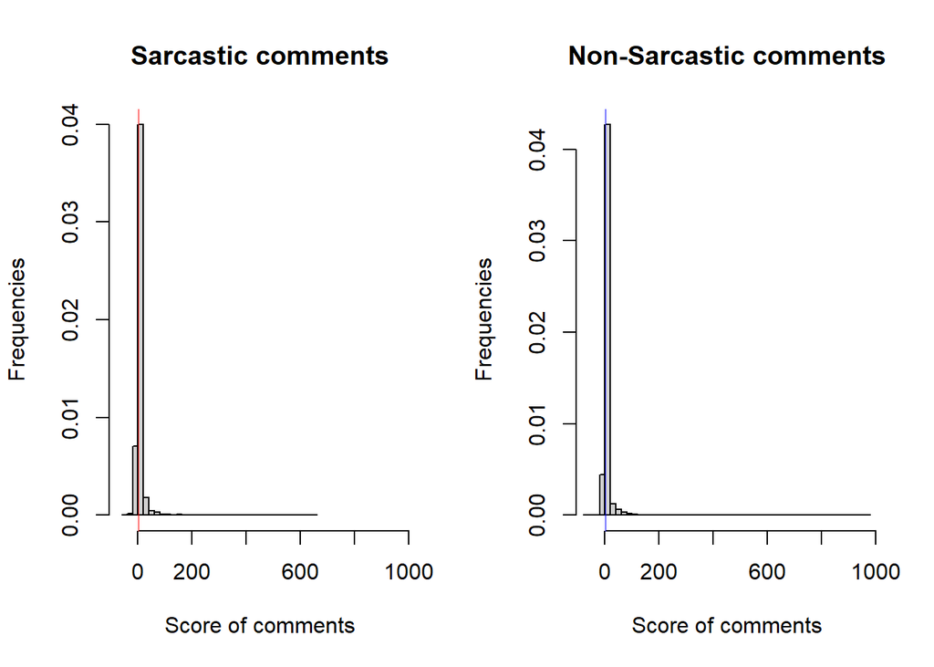

```r
#Score
par(mfrow=c(1,2))
#Plot the distribution of label =0
hist(sarc_df[sarc_df$label==1,]$score,  xlab="Score of comments", ylab="Frequencies", freq= FALSE, breaks =50, main="Sarcastic comments", xlim=c(min(sarc_df$score),max(sarc_df$score)))
abline(v=median(sarc_df[sarc_df$label==1,]$score),col="red",lwd=0.2)

hist(sarc_df[sarc_df$label==0,]$score,  xlab="Score of comments", ylab="Frequencies", freq= FALSE, breaks =50, main="Non-Sarcastic comments",xlim=c(min(sarc_df$score),max(sarc_df$score)))
abline(v=median(sarc_df[sarc_df$label==0,]$score),col="blue",lwd=0.2)
```

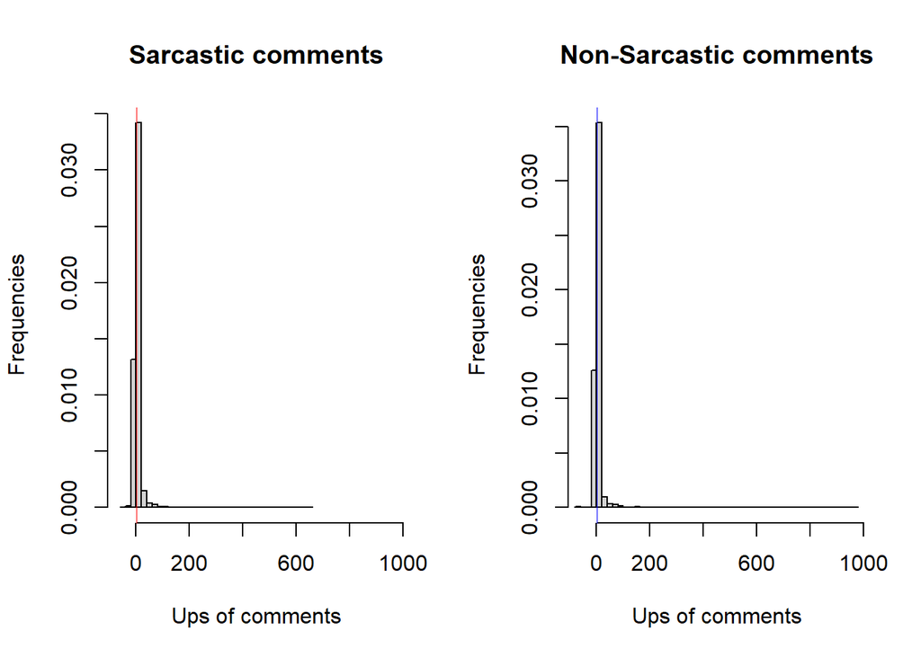

```r
#Ups
par(mfrow=c(1,2))
#Plot the distribution of label =0
hist(sarc_df[sarc_df$label==1,]$ups,  xlab="Ups of comments", ylab="Frequencies", freq= FALSE, breaks =50, main="Sarcastic comments", xlim=c(min(sarc_df$ups),max(sarc_df$ups)))
abline(v=median(sarc_df[sarc_df$label==1,]$ups),col="red",lwd=0.2)

hist(sarc_df[sarc_df$label==0,]$ups,  xlab="Ups of comments", ylab="Frequencies", freq= FALSE, breaks =50, main="Non-Sarcastic comments",xlim=c(min(sarc_df$ups),max(sarc_df$ups)))
abline(v=median(sarc_df[sarc_df$label==0,]$ups),col="blue",lwd=0.2)
```

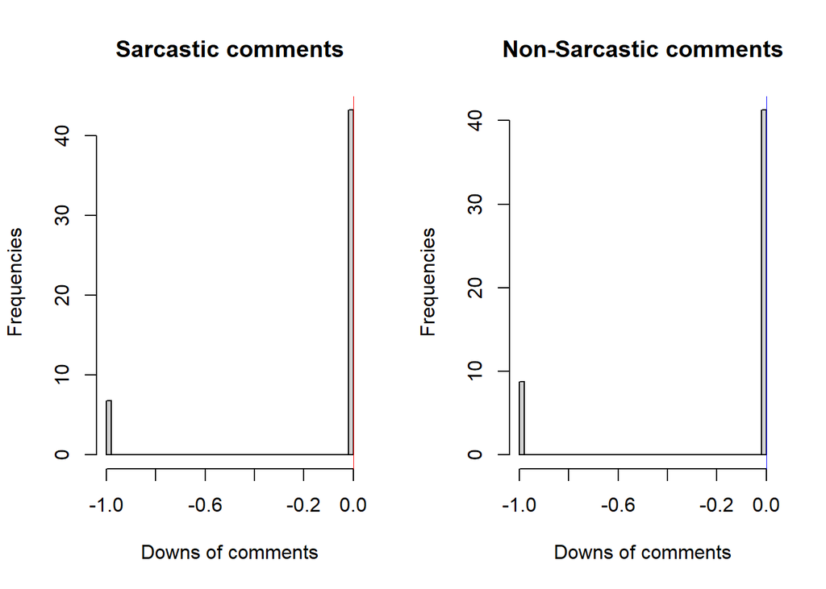

```r
#Downs
par(mfrow=c(1,2))
#Plot the distribution of label =0
hist(sarc_df[sarc_df$label==1,]$downs,  xlab="Downs of comments", ylab="Frequencies", freq= FALSE, breaks =50, main="Sarcastic comments", xlim=c(min(sarc_df$downs),max(sarc_df$downs)))
abline(v=median(sarc_df[sarc_df$label==1,]$downs),col="red",lwd=0.2)

hist(sarc_df[sarc_df$label==0,]$downs,  xlab="Downs of comments", ylab="Frequencies", freq= FALSE, breaks =50, main="Non-Sarcastic comments",xlim=c(min(sarc_df$downs),max(sarc_df$downs)))
abline(v=median(sarc_df[sarc_df$label==0,]$downs),col="blue",lwd=0.2)
```

#### Examine the relationship with other doc variables

```r
#docvars(sarc_corpus_1)
cat('\n Descriptive statistics for score in the sarcastic comments: \n ')
```

```
##
##  Descriptive statistics for score in the sarcastic comments:
##
```

```r
summary(sarc_corpus_1$score)
```

```
##    Min. 1st Qu.  Median    Mean 3rd Qu.    Max.
## -56.000   1.000   2.000   6.006   5.000 651.000
```

```r
cat('\n Descriptive statistics for score in the non-sarcastic comments: \n ')
```

```
##
##  Descriptive statistics for score in the non-sarcastic comments:
##
```

```r
summary(sarc_corpus_0$score)
```

```
##    Min. 1st Qu.  Median    Mean 3rd Qu.    Max.
## -65.000   1.000   2.000   7.534   4.000 966.000
```

```r
cat('\n Descriptive statistics for ups in the sarcastic comments: \n ')
```

```
##
##  Descriptive statistics for ups in the sarcastic comments:
##
```

```r
summary(sarc_corpus_1$ups)
```

```
##    Min. 1st Qu.  Median    Mean 3rd Qu.    Max.
## -56.000   0.000   1.000   4.848   4.000 651.000
```

```r
cat('\n Descriptive statistics for ups in the non-sarcastic comments: \n ')
```

```
##
##  Descriptive statistics for ups in the non-sarcastic comments:
##
```

```r
summary(sarc_corpus_0$ups)
```

```
##    Min. 1st Qu.  Median    Mean 3rd Qu.    Max.
## -65.000   0.000   1.000   5.607   3.000 966.000
```

```r
cat('\n Descriptive statistics for downs in the sarcastic comments: \n ')
```

```
##
##  Descriptive statistics for downs in the sarcastic comments:
##
```

```r
summary(sarc_corpus_1$downs)
```

```
##    Min. 1st Qu.  Median    Mean 3rd Qu.    Max.
## -1.0000  0.0000  0.0000 -0.1355  0.0000  0.0000
```

```r
cat('\n Descriptive statistics for downs in the non-sarcastic comments: \n ')
```

```
##
##  Descriptive statistics for downs in the non-sarcastic comments:
##
```

```r
summary(sarc_corpus_0$downs)
```

```
##    Min. 1st Qu.  Median    Mean 3rd Qu.    Max.
##  -1.000   0.000   0.000  -0.175   0.000   0.000
```

```r
#table(sarc_corpus_1$subreddit)
```

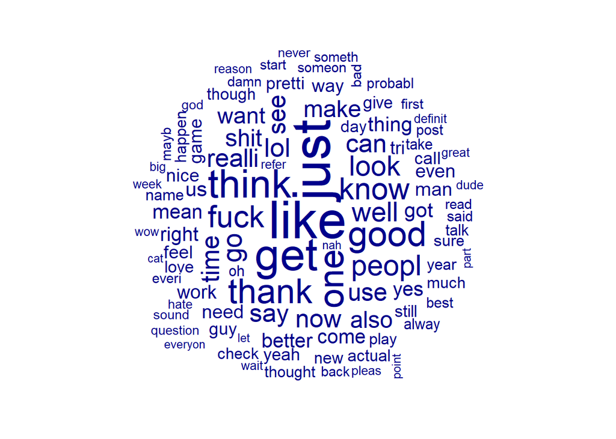

```r
#Without punctuation
textplot_wordcloud(dfm_0, max_words = 100, min_size = 0.5, max_size = 5)
```

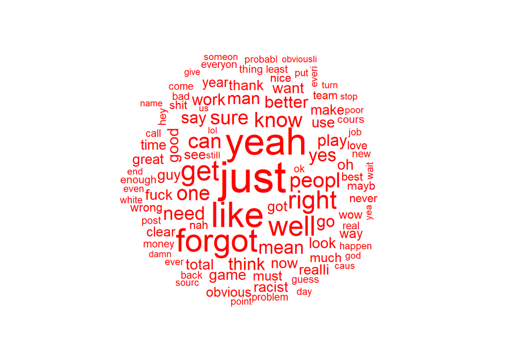

```r
textplot_wordcloud(dfm_1, max_words = 100, min_size = 0.5, max_size = 5,color = "red")
```

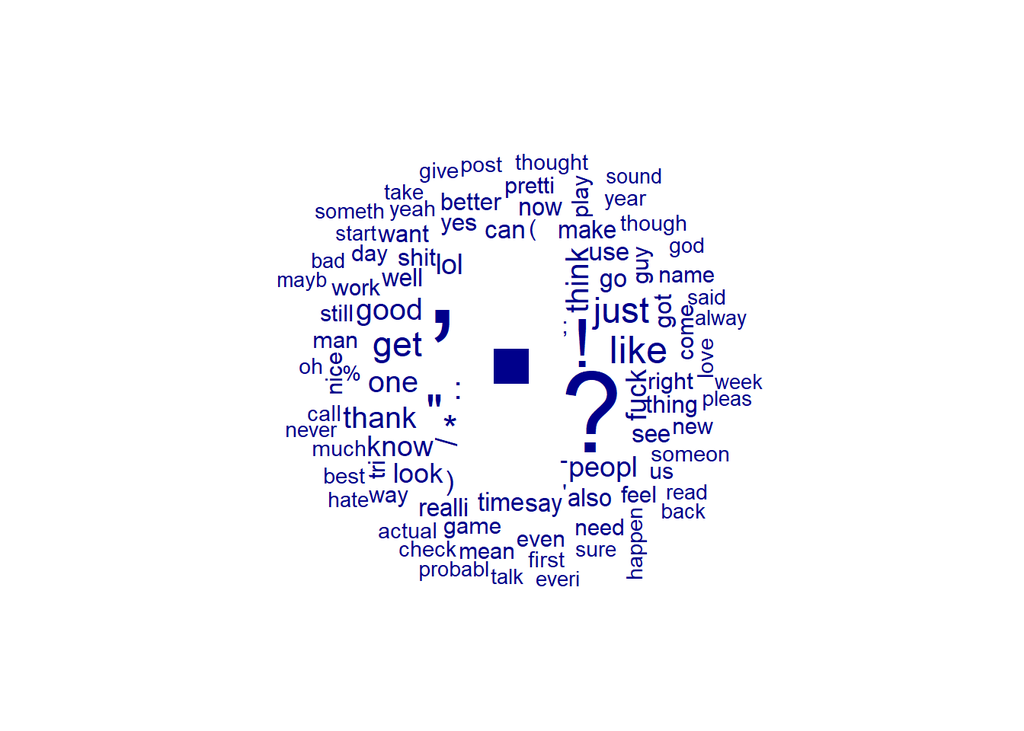

```r
#With punctuation
textplot_wordcloud(dfm_punct_0, max_words = 100, min_size = 1, max_size = 20)
```

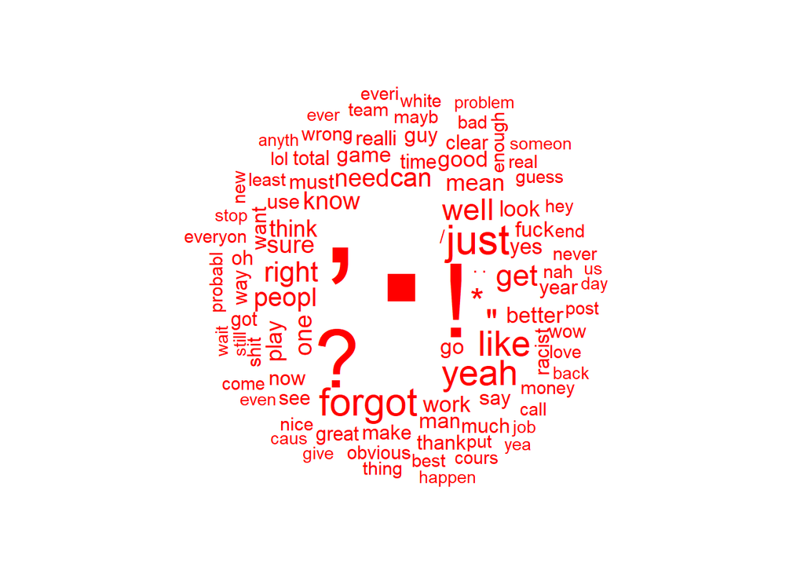

```r
textplot_wordcloud(dfm_punct_1, max_words = 100, min_size = 1, max_size = 20,color = "red")
```

```r
#---- Are sarcastic comments longer than others?

#count the number of tokens for each comment
sarc_word_toks_0_cnt<- ntoken(sarc_word_toks_0)
sarc_word_toks_1_cnt<- ntoken(sarc_word_toks_1)

#----For label = 0 --------------------
par(mfrow=c(1,2))
#Plot the distribution of label =0
hist(sarc_word_toks_0_cnt,  xlab="Number of tokens", ylab="Frequencies", freq= FALSE, breaks =20, main="Non-sarcastic comments", xlim=c(0,max(sarc_word_toks_0_cnt, sarc_word_toks_1_cnt)))

#Get descriptive statistics
cat('\n  These are the descriptive statistics for the length of the non-sarcastic comments \n ')
```

```
##
##   These are the descriptive statistics for the length of the non-sarcastic comments
##
```

```r
summary(sarc_word_toks_0_cnt)
```

```
##    Min. 1st Qu.  Median    Mean 3rd Qu.    Max.
##    1.00    6.00   10.00   12.41   17.00   96.00
```

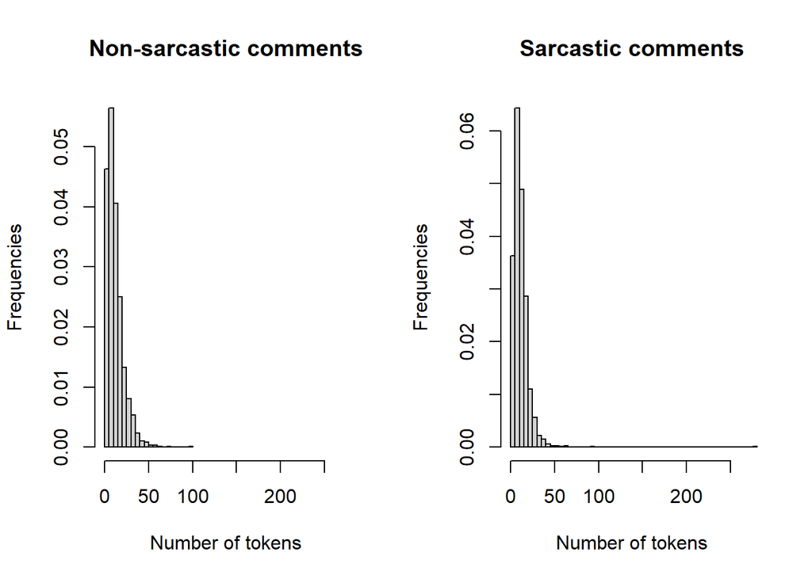

```r
#----For label = 1 --------------------


#Plot the distribution of label =0
hist(sarc_word_toks_1_cnt,  xlab="Number of tokens", ylab="Frequencies", freq= FALSE, breaks =40, main="Sarcastic comments",xlim=c(0,max(sarc_word_toks_0_cnt, sarc_word_toks_1_cnt)))
```

```r
#Get descriptive statistics
cat('\n These are the descriptive statistics for the length of the sarcastic comments \n ')
```

```
##
##  These are the descriptive statistics for the length of the sarcastic comments
##
```

```r
summary(sarc_word_toks_1_cnt)
```

```
##    Min. 1st Qu.  Median    Mean 3rd Qu.    Max.
##    1.00    7.00   10.00   12.08   16.00  276.00
```

```r
#----- Do sarcastic comments contain more punctuation than the non-sarcastic ones?


#Count the number of punctuations used in every comment
punctuation_0_cnt<- sarc_word_toks_0_cnt - ntoken(tokens(sarc_corpus_0, remove_punct = TRUE))
punctuation_1_cnt<- sarc_word_toks_1_cnt - ntoken(tokens(sarc_corpus_1, remove_punct = TRUE))

#----For non-sarcastic comments

#Plot the distribution of non-sarcastic comments
par(mfrow=c(1,2))
hist(punctuation_0_cnt,  xlab="Number of punctuations", ylab="Frequencies", freq= FALSE,breaks =50, main="Non-sarcastic comments",xlim=c(0,max(punctuation_1_cnt, punctuation_0_cnt)))

#Get descriptive statistics
cat('\n These are the descriptive statistics for the number of punctuations in the non-sarcastic comments \n')
```

```
##
##  These are the descriptive statistics for the number of punctuations in the non-sarcastic comments
```

```r
summary(punctuation_0_cnt)
```

```
##    Min. 1st Qu.  Median    Mean 3rd Qu.    Max.
##   0.000   1.000   1.000   1.698   2.000  46.000
```

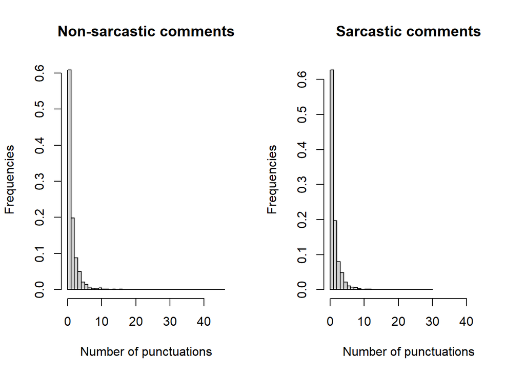

```r
#----For sarcastic comments

#Plot the distribution of sarcastic comments
hist(punctuation_1_cnt,  xlab="Number of punctuations", ylab="Frequencies", freq= FALSE,   breaks =40, main="Sarcastic comments",xlim=c(0,max(punctuation_1_cnt, punctuation_0_cnt)))
```

```r
#Get descriptive statistics
cat('\n These are the descriptive statistics for the number of punctuations in the sarcastic comments\n')
```

```
##
##  These are the descriptive statistics for the number of punctuations in the sarcastic comments
```

```r
summary(punctuation_1_cnt)
```

```
##    Min. 1st Qu.  Median    Mean 3rd Qu.    Max.
##   0.000   1.000   1.000   1.559   2.000  30.000
```

```r
#----- Does the text in the sarcastic comments have higher levels of complexity (lexical diversity and readability scores)?

#Since now we are not talking about length but about lexical diversity, I will remove stopwords from the analysis.

#------- For non-sarcastic comments  --------------------------------
toks_0 <- tokens_remove(sarc_word_toks_0, stopwords("english"))
dfm_0 <- dfm(toks_0)

# variations of TTR
tstat_lexdiv_0 <- textstat_lexdiv(dfm_0,measure="TTR")

#Get descriptive statistics
cat('\n Descriptive statistics of Lexical Diversity TTR measures for the non-sarcastic comments: \n ')
```

```
##
##  Descriptive statistics of Lexical Diversity TTR measures for the non-sarcastic comments:
##
```

```r
summary(tstat_lexdiv_0)
```

```
##    document              TTR
##  Length:2000        Min.   :0.500
##  Class :character   1st Qu.:1.000
##  Mode  :character   Median :1.000
##                     Mean   :0.986
##                     3rd Qu.:1.000
##                     Max.   :1.000
##                     NA's   :36
```

```r
#-------- For sarcastic comments  --------------------------------
toks_1 <- tokens_remove(sarc_word_toks_1, stopwords("english"))
dfm_1 <- dfm(toks_1)

# variations of TTR
tstat_lexdiv_1 <- textstat_lexdiv(dfm_1,measure="TTR")


#Get descriptive statistics
cat('\n Descriptive statistics of Lexical Diversity TTR measures for the sarcastic comments: \n ')
```

```
##
##  Descriptive statistics of Lexical Diversity TTR measures for the sarcastic comments:
##
```

```r
summary(tstat_lexdiv_1)
```

```
##    document              TTR
##  Length:2000        Min.   :0.400
##  Class :character   1st Qu.:1.000
##  Mode  :character   Median :1.000
##                     Mean   :0.992
##                     3rd Qu.:1.000
##                     Max.   :1.000
##                     NA's   :7
```

```r
#Readability

#-------For non-sarcastic comments --------------------------------
stat_read_0 <- textstat_readability(sarc_corpus_0,
                     measure = "Flesch.Kincaid")

#Get descriptive statistics
cat('\n Descriptive statistics for readability measure in the non-sarcastic comments: \n ')
```

```
##
##  Descriptive statistics for readability measure in the non-sarcastic comments:
##
```

```r
summary(stat_read_0)
```

```
##    document         Flesch.Kincaid
##  Length:2000        Min.   :-3.400
##  Class :character   1st Qu.: 1.475
##  Mode  :character   Median : 4.964
##                     Mean   : 5.365
##                     3rd Qu.: 8.400
##                     Max.   :43.800
##                     NA's   :2
```

```r
#------- For sarcastic comments  --------------------------------
stat_read_1 <- textstat_readability(sarc_corpus_1,
                     measure = "Flesch.Kincaid")

#Get descriptive statistics
cat('\n Descriptive statistics for readability measure in the sarcastic comments: \n ')
```

```
##
##  Descriptive statistics for readability measure in the sarcastic comments:
##
```

```r
summary(stat_read_1)
```

```
##    document         Flesch.Kincaid
##  Length:2000        Min.   :-3.400
##  Class :character   1st Qu.: 2.483
##  Mode  :character   Median : 5.230
##                     Mean   : 5.618
##                     3rd Qu.: 8.351
##                     Max.   :96.840
```

```r
#Test for independence between sarcasm and other metrics of the corpus
chisq.test(sarc_df$label, ntoken(toks))
```

```
##
##  Pearson's Chi-squared test
##
## data:  sarc_df$label and ntoken(toks)
## X-squared = 98.827, df = 31, p-value = 5.273e-09
```

```r
chisq.test(sarc_df$label, ntoken(toks)-ntoken(toks_punc))
```

```
##
##  Pearson's Chi-squared test
##
## data:  sarc_df$label and ntoken(toks) - ntoken(toks_punc)
## X-squared = 30.159, df = 19, p-value = 0.04981
```

```r
chisq.test(sarc_df$label, sarc_df$score)
```

```
##
##  Pearson's Chi-squared test
##
## data:  sarc_df$label and sarc_df$score
## X-squared = 198.54, df = 133, p-value = 0.0002001
```

```r
chisq.test(sarc_df$label, sarc_df$ups)
```

```
##
##  Pearson's Chi-squared test
##
## data:  sarc_df$label and sarc_df$ups
## X-squared = 172.45, df = 120, p-value = 0.001218
```

```r
chisq.test(sarc_df$label, sarc_df$downs)
```

```
##
##  Pearson's Chi-squared test with Yates' continuity correction
##
## data:  sarc_df$label and sarc_df$downs
## X-squared = 11.598, df = 1, p-value = 0.0006604
```

# —————————————————–

# Dictionaries

```r
library(quanteda.dictionaries)
```

### Is there a correlations with the sentiment and the sarcasm?

### Is there a correlation with the moral and the sarcasm?

Use the Moral Foundations Dictionary (`data_dictionary_MFD`) .

```r
#---------Sentiment of a comment:--------------------

#I will use the LexiCoder, which is built for media text and not for social media text, since Reddit comments are more similar to that. The authors in the paper have used the LIWC, but this is not an open source dictionary.

data(data_dictionary_LSD2015)
summary(data_dictionary_LSD2015)
```

```
##              Length Class  Mode
## negative     2858   -none- character
## positive     1709   -none- character
## neg_positive 1721   -none- character
## neg_negative 2860   -none- character
```

```r
#In this steps we are using monograms, hence the last 2 categories of the dictionary will not be used.


#Group the documents so that one group is for the ones that were sarcastic and the other for the ones that were not.
sarc_dfm_grp<- dfm_group(sarc_dfm_noprop, groups = label)

#Apply the sentiment dictionary to the dfm
sarc_dfm_sent <- dfm_lookup(sarc_dfm_grp, data_dictionary_LSD2015, verbose = TRUE)
```

```
## applying a dictionary consisting of 4 keys
```

```r
#Transform it to proportions, so that the magnitude of the 2 documents is indifferent
sarc_dfm_sent <- dfm_weight(sarc_dfm_sent, scheme = "prop")

#Print the results of the columns of interest
#I only use the first 2 since I have only created uni-gram tokens
sarc_dfm_sent[,0:2]
```

```
## Document-feature matrix of: 2 documents, 2 features (0.00% sparse) and 2 docvars.
##     features
## docs  negative  positive
##    0 0.3822064 0.6177936
##    1 0.4326409 0.5673591
```

```r
#---------Moral of a comment (Virtue or Vice):--------------------

#summary(data_dictionary_MFD) # This was used to look into the categories

# Aggregate the ten categories into 2 (virtue and vice). I generate a new dictionary.
moralDict <- dictionary(list(virtue = c(data_dictionary_MFD$care.virtue,
                                          data_dictionary_MFD$fairness.virtue,
                                        data_dictionary_MFD$loyalty.virtue,
                                        data_dictionary_MFD$authority.virtue,
                                        data_dictionary_MFD$sanctity.virtue),

                             vice =c(data_dictionary_MFD$care.vice,
                                     data_dictionary_MFD$fairness.vice,
                                     data_dictionary_MFD$loyalty.vice,
                                     data_dictionary_MFD$authority.vice,
                                     data_dictionary_MFD$sanctity.vice)))


#Apply the sentiment dictionary to the dfm
sarc_dfm_moral2 <- dfm_lookup(sarc_dfm_grp, moralDict, verbose = TRUE)
```

```
## applying a dictionary consisting of 2 keys
```

```r
#Transform it to proportions, so that the magnitude of the 2 documents is indifferent
sarc_dfm_moral2 <- dfm_weight(sarc_dfm_moral2, scheme = "prop")

#Print the results of the columns of interest
sarc_dfm_moral2
```

```
## Document-feature matrix of: 2 documents, 2 features (0.00% sparse) and 2 docvars.
##     features
## docs    virtue      vice
##    0 0.5576923 0.4423077
##    1 0.5022222 0.4977778
```

```r
#---------Moral of a comment (all categories):--------------------

#Apply the moral dictionary to the dfm
sarc_dfm_moral <- dfm_lookup(sarc_dfm_grp, data_dictionary_MFD, verbose = TRUE)
```

```
## applying a dictionary consisting of 10 keys
```

```r
#Transform it to proportions, so that the magnitude of the 2 documents is indifferent
sarc_dfm_moral <- dfm_weight(sarc_dfm_moral, scheme = "prop")

#Print the results of the columns of interest
sarc_dfm_moral
```

```
## Document-feature matrix of: 2 documents, 10 features (10.00% sparse) and 2 docvars.
##     features
## docs care.virtue care.vice fairness.virtue fairness.vice loyalty.virtue
##    0   0.2000000 0.1351351      0.06216216    0.03513514     0.06756757
##    1   0.1600877 0.1469298      0.06578947    0.13157895     0.08114035
##     features
## docs loyalty.vice authority.virtue authority.vice sanctity.virtue sanctity.vice
##    0            0        0.1486486    0.002702703      0.08648649     0.2621622
##    1            0        0.1140351    0.010964912      0.08771930     0.2017544
```

#### non-grouped for the comment

```r
#---------Sentiment of a parent comment:--------------------
#Apply the sentiment dictionary to the dfm
sarc_dfm_sent <- dfm_lookup(sarc_dfm_noprop, data_dictionary_LSD2015, verbose = TRUE)
```

```
## applying a dictionary consisting of 4 keys
```

```r
#Transform it to proportions, so that the magnitude of the 2 documents is indifferent
sarc_dfm_sent <- dfm_weight(sarc_dfm_sent, scheme = "prop")

#Print the results of the columns of interest
#I only use the first 2 since I have only created uni-gram tokens
sarc_dfm_sent[,0:2]
```

```
## Document-feature matrix of: 4,000 documents, 2 features (69.46% sparse) and 9 docvars.
##        features
## docs    negative positive
##   text1     0.75     0.25
##   text2     0        0
##   text3     0        0
##   text4     0        0
##   text5     0        0
##   text6     0        0
## [ reached max_ndoc ... 3,994 more documents ]
```

```r
#---------Moral of a comment (all categories):--------------------

#Apply the moral dictionary to the dfm
sarc_dfm_moral <- dfm_lookup(sarc_dfm_noprop, data_dictionary_MFD, verbose = TRUE)
```

```
## applying a dictionary consisting of 10 keys
```

```r
#Transform it to proportions, so that the magnitude of the 2 documents is indifferent
sarc_dfm_moral <- dfm_weight(sarc_dfm_moral, scheme = "prop")

#Print the results of the columns of interest
sarc_dfm_moral
```

```
## Document-feature matrix of: 4,000 documents, 10 features (98.07% sparse) and 9 docvars.
##        features
## docs    care.virtue care.vice fairness.virtue fairness.vice loyalty.virtue
##   text1           0         0               0             1              0
##   text2           0         0               0             0              0
##   text3           0         0               0             0              0
##   text4           0         0               0             0              0
##   text5           0         0               0             0              0
##   text6           0         0               0             0              0
##        features
## docs    loyalty.vice authority.virtue authority.vice sanctity.virtue
##   text1            0                0              0               0
##   text2            0                0              0               0
##   text3            0                0              0               0
##   text4            0                0              0               0
##   text5            0                0              0               0
##   text6            0                0              0               0
##        features
## docs    sanctity.vice
##   text1             0
##   text2             0
##   text3             0
##   text4             0
##   text5             0
##   text6             0
## [ reached max_ndoc ... 3,994 more documents ]
```

#### Create dictionary dfms for the parent-comment

```r
#---------Sentiment of a parent comment:--------------------

#Group the documents so that one group is for the ones that were sarcastic and the other for the ones that were not.
par_dfm_grp<- dfm_group(par_dfm_noprop, groups = label)

#Apply the sentiment dictionary to the dfm
par_dfm_sent <- dfm_lookup(par_dfm_grp, data_dictionary_LSD2015, verbose = TRUE)
```

```
## applying a dictionary consisting of 4 keys
```

```r
#Transform it to proportions, so that the magnitude of the 2 documents is indifferent
par_dfm_sent <- dfm_weight(par_dfm_sent, scheme = "prop")

#Print the results of the columns of interest
#I only use the first 2 since I have only created uni-gram tokens
par_dfm_sent[,0:2]
```

```
## Document-feature matrix of: 2 documents, 2 features (0.00% sparse) and 1 docvar.
##     features
## docs  negative  positive
##    0 0.4388245 0.5611755
##    1 0.4694750 0.5305250
```

```r
#---------Moral of a parent comment (all categories):--------------------

#Apply the moral dictionary to the dfm
sarc_dfm_moral2 <- dfm_lookup(par_dfm_grp, data_dictionary_MFD, verbose = TRUE)
```

```
## applying a dictionary consisting of 10 keys
```

```r
#Transform it to proportions, so that the magnitude of the 2 documents is indifferent
sarc_dfm_moral2 <- dfm_weight(sarc_dfm_moral2, scheme = "prop")

#Print the results of the columns of interest
sarc_dfm_moral2
```

```
## Document-feature matrix of: 2 documents, 10 features (0.00% sparse) and 1 docvar.
##     features
## docs care.virtue care.vice fairness.virtue fairness.vice loyalty.virtue
##    0   0.1777996 0.1552063      0.07563851    0.04223969     0.08447937
##    1   0.1604278 0.1497326      0.06203209    0.05668449     0.10909091
##     features
## docs loyalty.vice authority.virtue authority.vice sanctity.virtue sanctity.vice
##    0  0.001964637        0.1296660    0.004911591      0.11886051     0.2092338
##    1  0.001069519        0.1262032    0.011764706      0.09411765     0.2288770
```

#### Non-grouped:

```r
#---------Sentiment of a parent comment:--------------------
#Apply the sentiment dictionary to the dfm
par_dfm_sent <- dfm_lookup(par_dfm_noprop, data_dictionary_LSD2015, verbose = TRUE)
```

```
## applying a dictionary consisting of 4 keys
```

```r
#Transform it to proportions, so that the magnitude of the documents is indifferent
par_dfm_sent <- dfm_weight(par_dfm_sent, scheme = "prop")

#Print the results of the columns of interest
#I only use the first 2 since I have only created uni-gram tokens
par_dfm_sent[,0:2]
```

```
## Document-feature matrix of: 4,000 documents, 2 features (56.89% sparse) and 8 docvars.
##        features
## docs    negative positive
##   text1      0        0
##   text2      0        1.0
##   text3      0.5      0.5
##   text4      0        1.0
##   text5      1.0      0
##   text6      0        0
## [ reached max_ndoc ... 3,994 more documents ]
```

```r
#---------Moral of a parent comment (all categories):--------------------

#Apply the moral dictionary to the dfm
par_dfm_moral <- dfm_lookup(par_dfm_noprop, data_dictionary_MFD, verbose = TRUE)
```

```
## applying a dictionary consisting of 10 keys
```

```r
#Transform it to proportions, so that the magnitude of the 2 documents is indifferent
par_dfm_moral <- dfm_weight(par_dfm_moral, scheme = "prop")

#Print the results of the columns of interest
par_dfm_moral
```

```
## Document-feature matrix of: 4,000 documents, 10 features (96.14% sparse) and 8 docvars.
##        features
## docs    care.virtue care.vice fairness.virtue fairness.vice loyalty.virtue
##   text1           0         0               0             0              0
##   text2           0         0               0             0              0
##   text3           1         0               0             0              0
##   text4           0         0               0             0              0
##   text5           0         0               0             0              0
##   text6           0         0               0             0              0
##        features
## docs    loyalty.vice authority.virtue authority.vice sanctity.virtue
##   text1            0                0              0               0
##   text2            0                0              0               0
##   text3            0                0              0               0
##   text4            0                0              0               0
##   text5            0                0              0               0
##   text6            0                0              0               0
##        features
## docs    sanctity.vice
##   text1             0
##   text2             0
##   text3             0
##   text4             0
##   text5             0
##   text6             0
## [ reached max_ndoc ... 3,994 more documents ]
```

#### Calculate distance between parent and comment regarding morality

Compute a metric of distance between parent comment and comment. Do this for each row of the dataset and calculate cosine similarity.

```r
#initialize the distance numeric vector
distance<- vector('numeric',length(toks))

#process each record separately
for (i in sequence(length(toks))){
  #create a weighted dfm of the post
  par_dfm_tmp<- par_dfm_moral[i,]

  #create a weighted dfm of the comment
  sarc_dfm_tmp<- sarc_dfm_moral[i,]

  #calculate cosine similarity and reduce it from 1 in order to get the distance
  distance[i] <-1 - sum(par_dfm_tmp * sarc_dfm_tmp) / ( sqrt(sum(par_dfm_tmp^2)) *  sqrt(sum(sarc_dfm_tmp^2)) )
}
```

```r
#Create a dataframe with distance and label

distance_label_df<- data.frame(distance, sarc_df$label)
colnames(distance_label_df)<- c('distance', 'label')

#Seperate them on label = 0 and label = 1
distance_0<- distance_label_df[distance_label_df$label ==0,1]
distance_1<- distance_label_df[distance_label_df$label ==1,1]

#----For label = 0
par(mfrow=c(1,2))
#Plot the distribution of delta =0
hist(distance_0,  xlab="Moral distance", ylab="Frequencies", freq= FALSE, breaks =10, main="Non-sarcastic comments", ylim=c(0,7))
#ylim = c(0, 0.014), xlim= c(0,700), breaks =10
#Get descriptive statistics
cat('\n Descriptive statistics for the moral distance between parent-comment and non-sarcastic comment\n')
```

```
##
##  Descriptive statistics for the moral distance between parent-comment and non-sarcastic comment
```

```r
summary(distance_0)
```

```
##    Min. 1st Qu.  Median    Mean 3rd Qu.    Max.    NA's
##  0.0000  0.0000  1.0000  0.5925  1.0000  1.0000    1876
```

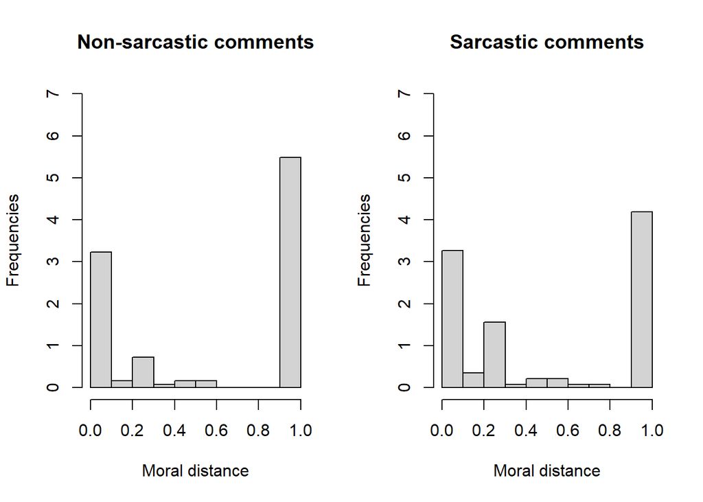

```r
#----For label = 1
#Plot the distribution of delta =1
hist(distance_1,  xlab="Moral distance", ylab="Frequencies", freq= FALSE, breaks =10,main="Sarcastic comments",ylim=c(0,7))
```

```r
#Get descriptive statistics
cat('\n Descriptive statistics for the moral distance between parent-comment and sarcastic comment\n')
```

```
##
##  Descriptive statistics for the moral distance between parent-comment and sarcastic comment
```

```r
summary(distance_1)
```

```
##    Min. 1st Qu.  Median    Mean 3rd Qu.    Max.    NA's
##  0.0000  0.0000  0.2929  0.5043  1.0000  1.0000    1859
```

#### Is there a correlation between how moral a parent-comment is and how sarcastic the answer will be?

```r
#---------Moral (virtue or vice) of a parent comment:--------------------
#Group the documents so that one group is for the ones that were persuaded and the other for the ones that were not.
par_dfm_grp<- dfm_group(par_dfm_noprop, groups = label)

#Apply the sentiment dictionary to the dfm
par_dfm_grp <- dfm_lookup(par_dfm_grp, moralDict, verbose = TRUE)
```

```
## applying a dictionary consisting of 2 keys
```

```r
#Transform it to proportions, so that the magnitude of the 2 documents is indifferent
par_dfm_grp <- dfm_weight(par_dfm_grp, scheme = "prop")

#Print the results of the columns of interest
par_dfm_grp
```

```
## Document-feature matrix of: 2 documents, 2 features (0.00% sparse) and 1 docvar.
##     features
## docs    virtue      vice
##    0 0.5858283 0.4141717
##    1 0.5495103 0.4504897
```

# —————————————————–

# Supervised Learning

## Naive Bayes

The code here illustrates how we can use supervised machine learning to predict categories for unseen documents based on a set of labeled documents.

We take an 80% random sample of comments as training set and the rest as test set, which we will use to compute the performance of our model. We will then create a document-feature-matrix where each variable is a word.

```r
# shuffling to split into training and test set
smp <- sample(c("train", "test"), size=ndoc(sarc_corpus),
                prob=c(0.80, 0.20), replace=TRUE)
train <- which(smp=="train")
test <- which(smp=="test")
```

Train a Naive Bayes model:

```r
# training Naive Bayes model
nb <- textmodel_nb(sarc_dfm[train,], docvars(sarc_corpus, "label")[train])
# predicting labels for test set
preds <- predict(nb, newdata = sarc_dfm[test,])

# computing the confusion matrix
cm <- table(preds, docvars(sarc_corpus, "label")[test])#compares training vs test
```

We compute precision, recall, and accuracy to quantify how well the Naive Bayes model performed.

```r
# function to compute performance metrics
precrecall <- function(mytable, verbose=TRUE) {
    truePositives <- mytable[1,1]
    falsePositives <- sum(mytable[1,]) - truePositives
    falseNegatives <- sum(mytable[,1]) - truePositives
    precision <- truePositives / (truePositives + falsePositives)
    recall <- truePositives / (truePositives + falseNegatives)
    if (verbose) {
        print(mytable)
        cat("\n precision =", round(precision, 2),
            "\n    recall =", round(recall, 2), "\n")
    }
    invisible(c(precision, recall))
}
```

```r
#Reverse the index of the confusion matrix 'cm' aso that the positive class to predict is the label=1
cm_rev <- cm[2:1,2:1]
cm_rev
```

```
##
## preds   1   0
##     1 201 152
##     0 170 259
```

```r
cat('\n')
```

```r
# precision and recall
p_r<-precrecall(cm_rev, verbose = FALSE)
cat("precision =", round(p_r[1], 2),
            "\nrecall =", round(p_r[2], 2), "\n")
```

```
## precision = 0.57
## recall = 0.54
```

```r
#F1 score
f1<- (2*(p_r[1]*p_r[2]))/(p_r[1]+p_r[2])
cat("F1 score =", round(f1,2), "\n")
```

```
## F1 score = 0.56
```

```r
#accuracy
cat('accuracy =', round(sum(diag(cm_rev)) / sum(cm_rev),2))
```

```
## accuracy = 0.59
```

What if we try with word n-grams up to bigrams instead of unigrams?

```r
# Naive Bayes model
nb <- textmodel_nb(sarc_bg_dfm[train,], docvars(sarc_corpus, "label")[train])
preds <- predict(nb, newdata = sarc_bg_dfm[test,])

#performance
cm <- table(preds, docvars(sarc_corpus, "label")[test])
cm_rev <- cm[2:1,2:1]
cm_rev
```

```
##
## preds   1   0
##     1 204 153
##     0 167 258
```

```r
cat('\n')
```

```r
# precision and recall
p_r<-precrecall(cm_rev, verbose = FALSE)
cat("precision =", round(p_r[1], 2),
            "\nrecall =", round(p_r[2], 2), "\n")
```

```
## precision = 0.57
## recall = 0.55
```

```r
#F1 score
f1<- (2*(p_r[1]*p_r[2]))/(p_r[1]+p_r[2])
cat("F1 score =", round(f1,2), "\n")
```

```
## F1 score = 0.56
```

```r
#accuracy
cat('accuracy =', round(sum(diag(cm_rev)) / sum(cm_rev),2))
```

```
## accuracy = 0.59
```

We dig a bit more into the model by extracting the posterior class probabilities for words than in the worcloud came up as frequent ones in one of the 2 categories.

```r
# extracting posterior word probabilities
get_posterior <- function(nb) {
  PwGc <- nb$param #prob of the word Given class
  Pc <- nb$priors #prob of the class
  PcGw <- PwGc * base::outer(Pc, rep(1, ncol(PwGc)))
  PcGw <- matrix(sapply(PcGw, function(x) sqrt(sum(x^2))), nrow=2, dimnames = dimnames(PwGc)) #prob of the class (of the doc) given the word
  names(dimnames(PcGw))[1] <- names(dimnames(PwGc))[1] <- "classes"
  PcGw
}
probs <- get_posterior(nb)
probs[,c("forgot", "yeah", "good", "thank")]
```

```
##        NA
## classes       forgot        yeah        good       thank
##       0 0.0003996331 0.000929732 0.001666684 0.001596960
##       1 0.0027653636 0.003190550 0.001315462 0.001201945
```

```r
#To do: get the ones with the highest prob
```

Lasso regression. The number of features will change depending on the value of the penalty parameter.

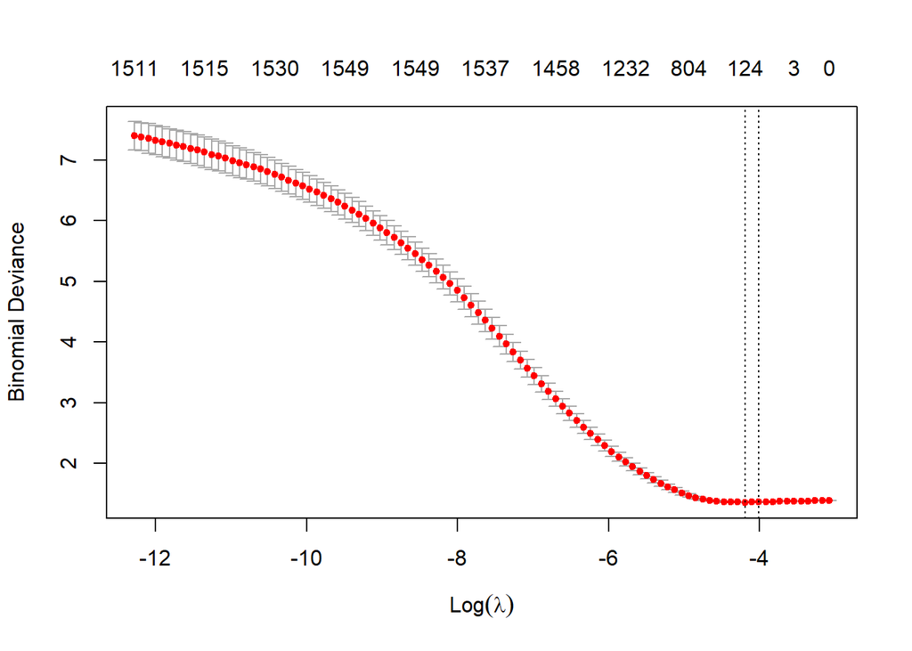

```r
# now with lasso
lasso <- cv.glmnet(x=sarc_bg_dfm[train,], y=docvars(sarc_corpus, "label")[train],
                   alpha=1, nfolds=5, family="binomial")
plot(lasso)
```

```r
pred <- predict(lasso, sarc_bg_dfm[test,], type="class")

#performance
cm <- table(pred, docvars(sarc_corpus, "label")[test])
cm_rev <- cm[2:1,2:1]
cm_rev
```

```
##
## pred   1   0
##    1  90  34
##    0 281 377
```

```r
cat('\n')
```

```r
# precision and recall
p_r<-precrecall(cm_rev, verbose = FALSE)
cat("precision =", round(p_r[1], 2),
            "\nrecall =", round(p_r[2], 2), "\n")
```

```
## precision = 0.73
## recall = 0.24
```

```r
#F1 score
f1<- (2*(p_r[1]*p_r[2]))/(p_r[1]+p_r[2])
cat("F1 score =", round(f1,2), "\n")
```

```
## F1 score = 0.36
```

```r
#accuracy
cat('accuracy =', round(sum(diag(cm_rev)) / sum(cm_rev),2))
```

```
## accuracy = 0.6
```

```r
# extracting coefficients
best.lambda <- which(lasso$lambda==lasso$lambda.1se)
beta <- lasso$glmnet.fit$beta[,best.lambda]

length(beta)#The number of features when training the model
```

```
## [1] 1734
```

```r
sum(beta!=0)#The number of features selected from the model.
```

```
## [1] 45
```

```r
best.lambda#best lambda
```

```
## [1] 11
```

```r
## identifying predictive features
df <- data.frame(coef = as.numeric(beta),
                ngram = names(beta), stringsAsFactors=F)

# note that some features become 0
table(df$coef==0)
```

```
##
## FALSE  TRUE
##    45  1689
```

```r
df <- df[order(df$coef),]
head(df[,c("coef", "ngram")], n=10)
```

```
##            coef   ngram
## 151  -1.7974220    week
## 448  -1.6442746  awesom
## 389  -1.1661142    also
## 271  -1.0435673  actual
## 1095 -0.8368115  parent
## 563  -0.4729449   illeg
## 169  -0.4122014   pleas
## 922  -0.3298982  remind
## 63   -0.2814957    read
## 484  -0.2497176 product
```

```r
tail(df[,c("coef", "ngram")], n=10)
```

```
##         coef   ngram
## 266 1.172883   total
## 614 1.222019     kid
## 34  1.320905   clear
## 935 1.428866     bro
## 585 1.491472    caus
## 479 1.679268 obvious
## 219 1.783663   fault
## 24  2.601553    yeah
## 681 2.908973    rape
## 74  4.474297    hard
```

For the words that came up as the most significant ones from the previous model, I search them in their content. I print only 5 comments.

```r
kwic(toks_bg, "yeah", window =10)[1:5,]
```

```
## Keyword-in-context with 5 matches.
##   [text7, 1]      | Yeah |
##  [text18, 1]      | Yeah |
##  [text48, 1]      | Yeah |
##  [text49, 2] Well | yeah |
##  [text66, 1]      | Yeah |
##
##  now NSA steal nude Yeah_now now_NSA NSA_steal steal_nude
##  mean like author book ever talk show creator probabl even
##  wait start behind safeti car either Yeah_wait wait_start start_behind behind_safeti
##  one team get Olympian Well_yeah yeah_one one_team team_get get_Olympian
##  riot bugsplat certain fault Yeah_riot riot_bugsplat bugsplat_certain certain_fault
```

```r
#To do: get the actual label next to the kwic df
#cbind(k,toks_bg$label)
```

# ——————————————————–

# Disimilarity metric

#### Are comments different from their parent-comments less likely to be sarcastic?

Calculate distance between parent and comment.

Compute a metric of distance between parent comment and comment. Do this for each row of the dataset and calculate cosine similarity.

```r
#initialize the distance numeric vector
distance<- vector('numeric',length(toks))


#process each record separately
for (i in sequence(length(toks))){
  #create a weighted dfm of the post
  par_dfm_tmp<- par_dfm[i,]

  #create a weighted dfm of the comment
  sarc_dfm_tmp<- sarc_dfm[i,]

  #get the posts dfm that also includes features from the comment dfm
  par_dfm_full<- dfm_match(par_dfm_tmp,union(featnames(par_dfm_tmp), featnames(sarc_dfm_tmp)))

  #get the comments dfm that also includes features from the posts dfm
  sarc_dfm_full<- dfm_match(sarc_dfm_tmp,union(featnames(par_dfm_tmp), featnames(sarc_dfm_tmp)))

  #calculate cosine similarity and reduce it from 1 in order to get the distance
  distance[i] <-1 - sum(par_dfm_full * sarc_dfm_full) / ( sqrt(sum(par_dfm_full^2)) *  sqrt(sum(sarc_dfm_full^2)) )
}
```

```r
#Create a dataframe with distance and label

distance_label_df<- data.frame(distance, sarc_df$label)
colnames(distance_label_df)<- c('distance', 'label')

#Seperate them on label = 0 and label = 1
distance_0<- distance_label_df[distance_label_df$label ==0,1]
distance_1<- distance_label_df[distance_label_df$label ==1,1]

#----For label = 0
par(mfrow=c(1,2))
#Plot the distribution of delta =0
hist(distance_0,  xlab="Distance", ylab="Frequencies", freq= FALSE, breaks =20, main="Non-sarcastic comments",  ylim=c(0,15))
#ylim = c(0, 0.014), xlim= c(0,700), breaks =10
#Get descriptive statistics
cat('\n Descriptive statistics for the distance between parent-comment and non-sarcastic comment\n')
```

```
##
##  Descriptive statistics for the distance between parent-comment and non-sarcastic comment
```

```r
summary(distance_0)
```

```
##    Min. 1st Qu.  Median    Mean 3rd Qu.    Max.    NA's
##  0.0000  0.8687  1.0000  0.9169  1.0000  1.0000     241
```

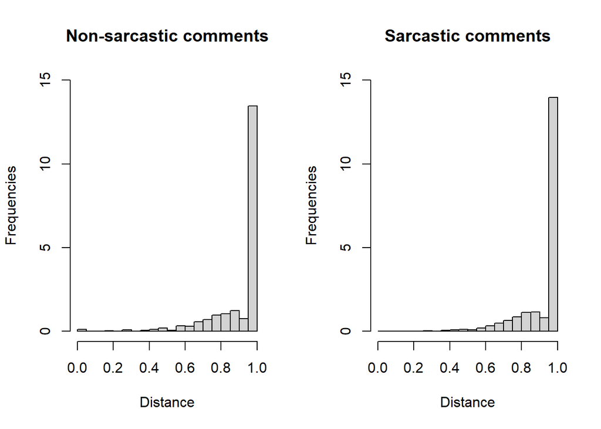

```r
#----For label = 1
#Plot the distribution of delta =1
hist(distance_1,  xlab="Distance", ylab="Frequencies", freq= FALSE, breaks =20,main="Sarcastic comments", ylim=c(0,15))
```

```r
#Get descriptive statistics
cat('\n Descriptive statistics for the distance between parent-comment and sarcastic comment\n')
```

```
##
##  Descriptive statistics for the distance between parent-comment and sarcastic comment
```

```r
summary(distance_1)
```

```
##    Min. 1st Qu.  Median    Mean 3rd Qu.    Max.    NA's
##  0.0000  0.8882  1.0000  0.9316  1.0000  1.0000     126
```

# ————————————————

# Topic Modeling

```r
library("stm")
library("tidyverse")
library("zoo")
library("topicmodels", quietly = TRUE, warn.conflicts = FALSE, verbose = FALSE)
```

Converting the `quanteda` object into an input for the structural topic model:

```r
stm_input <- convert(sarc_dfm_noprop, to = "stm")
```

[output not shown]

## Select the optimal number of topics (k)

```r
k_search_output <- searchK(stm_input$documents, stm_input$vocab,
                           K = c(4,6,8,10,12), data = stm_input$meta,
                           verbose = FALSE, heldout.seed = 123)
plot(k_search_output)
k_search_output
```

[output not shown]

```r
#k_search_output$results %>%
#  select(K, exclus, semcoh) %>%
#  unnest() %>%
#  mutate(K = as.factor(K)) %>%
 # ggplot(aes(semcoh, exclus, color = K)) +
 # geom_point(size = 3, alpha = 0.7) +
  #labs(x = "Semantic coherence",
  #     y = "Exclusivity",
   #    title = "Exclusivity and semantic coherence for different number of topics")
```

## Fitting a topic model with topic prevalence covariates

We choose k=6. When estimating the topic model, we provide the label as topic prevalence covariate and do not specify any topic content covariates for now.

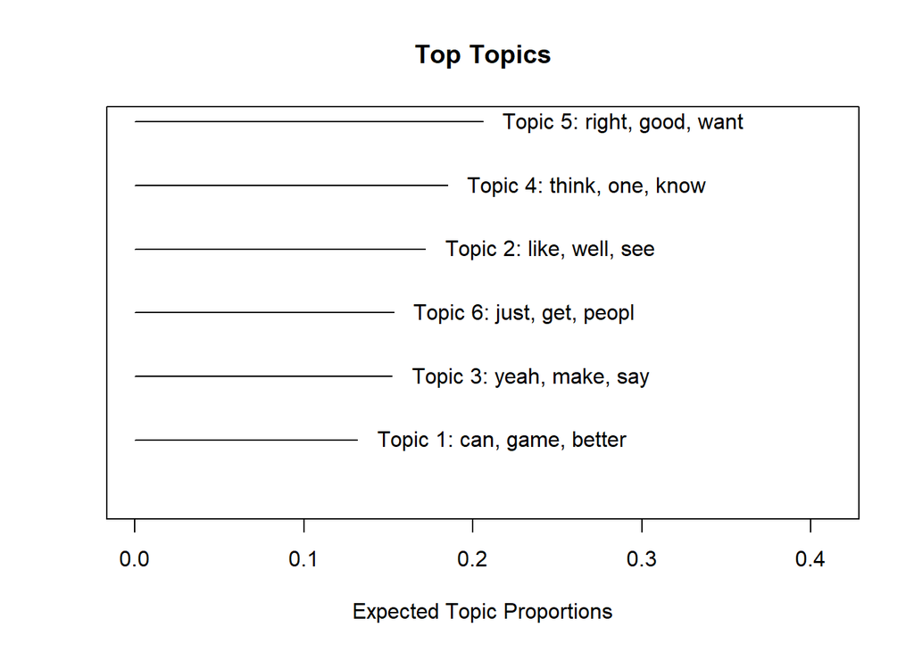

```r
stmodel <- stm(documents = stm_input$documents, vocab = stm_input$vocab,
                     K = 6, prevalence =~ label_f ,
               data = stm_input$meta, verbose = FALSE, init.type = "Spectral")

#prevalence: there might be different topic shares in the thetas depending ont he party and the year

plot(stmodel)
```

And individual word clouds for each topic. We can see the different structures.

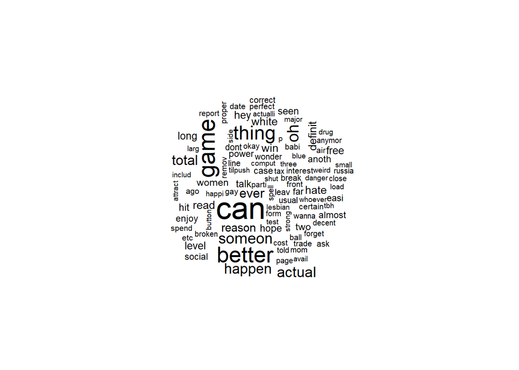

```r
set.seed(123)
cloud(stmodel, topic = 1, scale = c(2.5,.5))
```

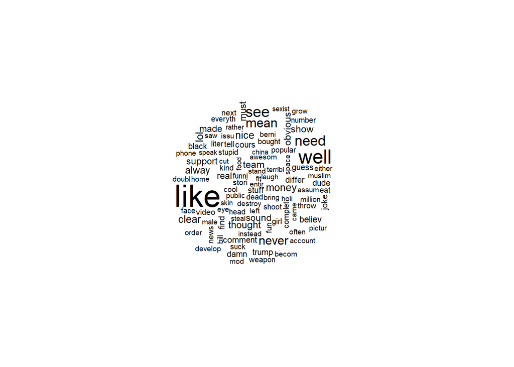

```r
cloud(stmodel, topic = 2, scale = c(2.5,.5))
```

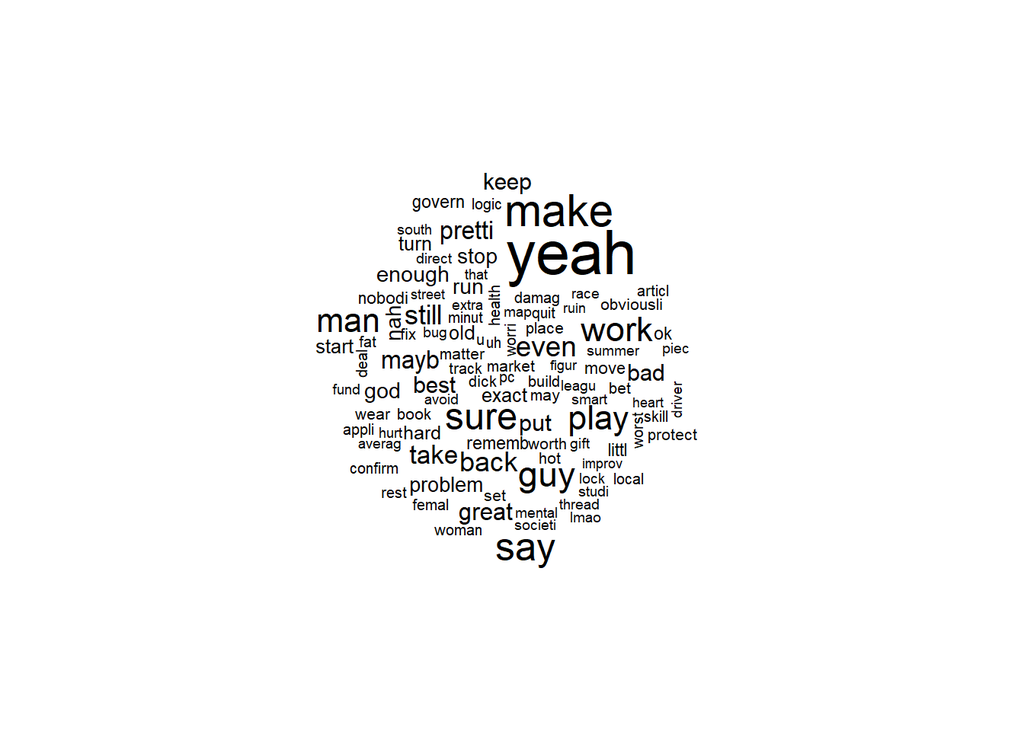

```r
cloud(stmodel, topic = 3, scale = c(2.5,.5))
```

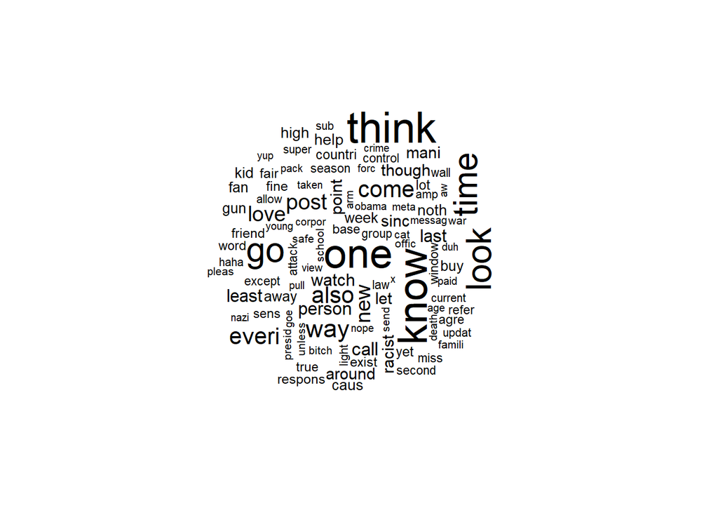

```r
cloud(stmodel, topic = 4, scale = c(2.5,.5))
```

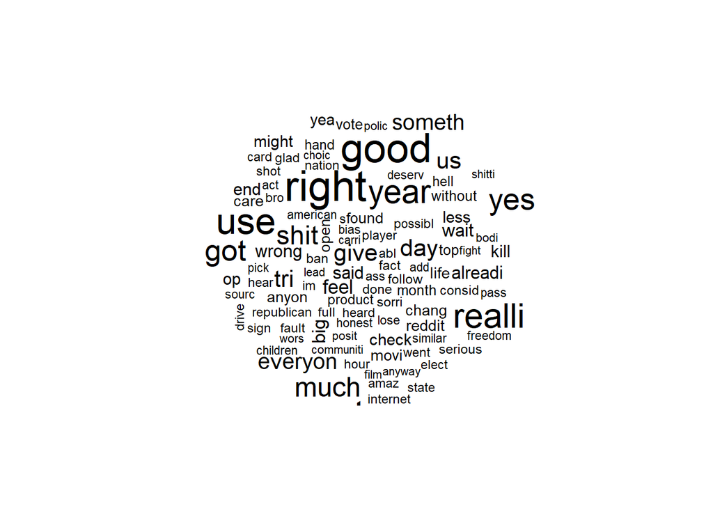

```r
cloud(stmodel, topic = 5, scale = c(2.5,.5))
```

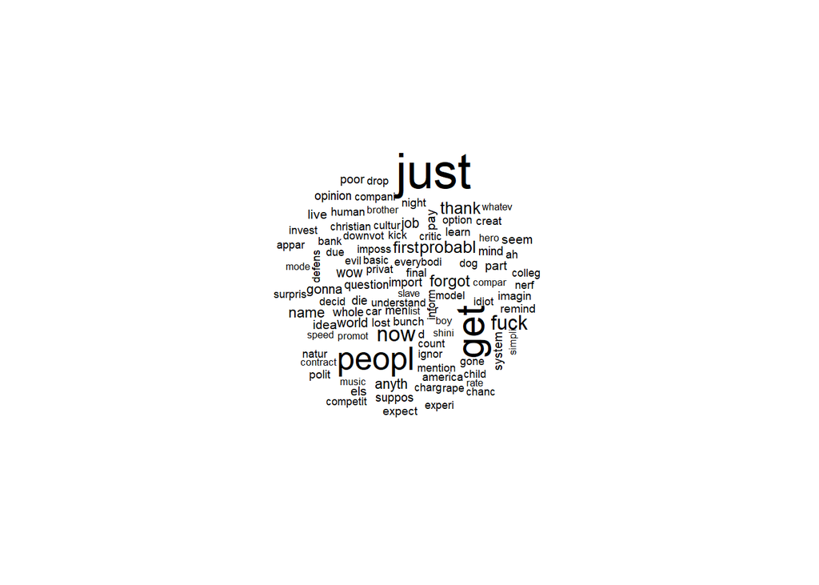

```r
cloud(stmodel, topic = 6, scale = c(2.5,.5))
```

Let us now look into documents which have high shares of these topics and see whether the topic assignment makes sense. This can be done with the function `findThoughts`. We will look at only 2 examples to illustrate the functionality, but of course reading of more articles would be necessary for a careful analysis.

```r
for (i in sequence(6)){
  x<-findThoughts(stmodel,texts = sarc_df$comment[rowSums(sarc_dfm_noprop)>0],
                                    n = 2, topics = i)$docs[[1]]
  cat("\n Most representative documents for topic",i,": \n")
  print(x)
}
```

```
##
##  Most representative documents for topic 1 :
## [1] "Level 5 - barbs, archers, giants, wizards Level 4 - goblins, , balloons Level 3 - healer Level 2 - dragon, hogs, minions Level 1 - pekka, valkyries == Level 5 - lightning spell Level 4 - heal/rage spell Level 6 barb king"
## [2] "That's the beauty of modern whisky collecting and enjoyment: you can just read someone else's enjoyment or displeasure of a certain bottle, so you can keep yours sealed forever as a shelf ornament."
##
##  Most representative documents for topic 2 :
## [1] "Right, but if you asked them what food to bring they would ask to not bring meat, and it would be a dick move to bring it if you knew that already, meaning that the kind of people who do bring offerings wouldn't bring meat."
## [2] "I was kind of laughing my ass off at that comment, guys sounds like a damn child."
##
##  Most representative documents for topic 3 :
## [1] "You're assuming that you have any right to the fruits of your labor, and that it's not a gift from ~~God~~ the government, which you should always ~~offer back~~ surrender to ~~God~~ the government, because you're participating in \"secular society.\""
## [2] "Yeah man, let's take a fantastic map, with some of the best CT-T balance out of all the maps, that has been a staple of the game for a decade, and remove it because people play it too much."
##
##  Most representative documents for topic 4 :
## [1] "I only smoke 1 or 2 joints a week of prescribed because I am not a pathetic druggie with nothing better to do, but it definitely helps with stress relief, drinking less alcohol and smoking less cigarettes."
## [2] "That doesn't count because he was one of the \"highly trained\" police officers that are the only ones that should have access to \"those types\" of weapons."
##
##  Most representative documents for topic 5 :
## [1] "Good thing the Republicans are for following the law of the land, which is the Constitution and which specifically states about freedom of religion."
## [2] "Yes, because army medics lead to a false sense of security, which leads to soldiers allowing themselves to get shot."
##
##  Most representative documents for topic 6 :
## [1] "While I really appreciate the offer, I'm just fine with what I have now, thanks :p Just keep practising, if the downvotes don't bother you each time you post you'll often get sound criticism from some people who can guide you in the right direction."
## [2] "At least the same peep who created PPRNG has also managed to create this SAV dumper tool, for a more legit shiny egg :D"
```

The prevalence covariate allow to see which topics are discussed more by which of the two groups:

```r
effect_estimates <- estimateEffect(1:6 ~ label_f, stmodel, meta = stm_input$meta)
```

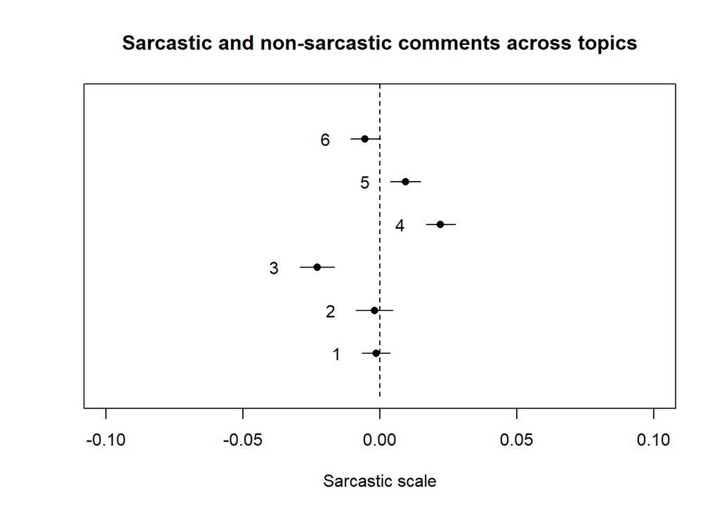

```r
plot(effect_estimates, covariate = "label_f", topics = c(1, 2, 3, 4,5,6),
     model = stmodel, method = "difference",
     cov.value1 = "1", cov.value2 = "0",
     xlab = "Sarcastic scale",
     main = "Sarcastic and non-sarcastic comments across topics",
     xlim = c(-.1, .1), labeltype = "custom",
     #custom.labels = c("Topic1", "Topic2")
     )
```

## Fitting a topic model with topic prevalence and topic content covariates

Next, we fit another structural topic model with both prevalence and topic content covariates. This allows to not just analyse how topic shares within documents vary cross different groups, but also how words in topics vary. The following will take a longer time to run than the previous model because of the additional covariate.

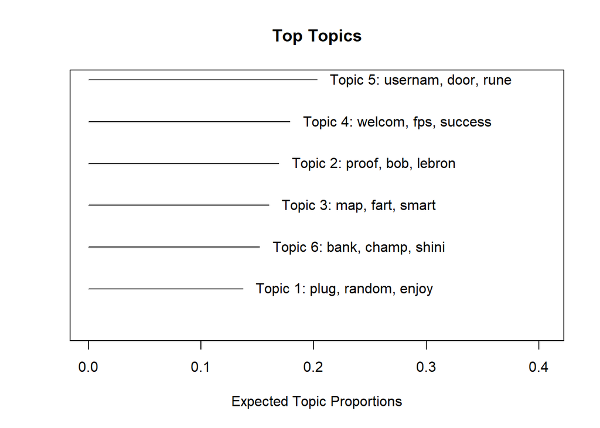

```r
stmodel_add <- stm(documents = stm_input$documents, vocab = stm_input$vocab,
                     K = 6, prevalence =~ label_f  + s(score), content =~ label_f ,
               data = stm_input$meta, verbose = FALSE, init.type = "Spectral")

#prevalence: there might be different topic shares in the thetas depending ont he party and the year

plot(stmodel_add)
```

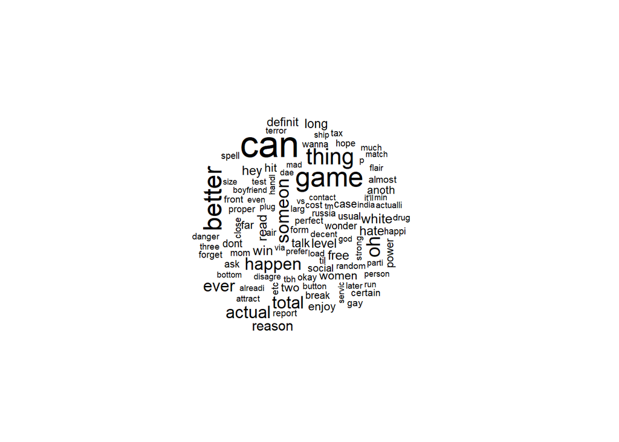

```r
set.seed(123)
cloud(stmodel_add, topic = 1, scale = c(2.5,.5))
```

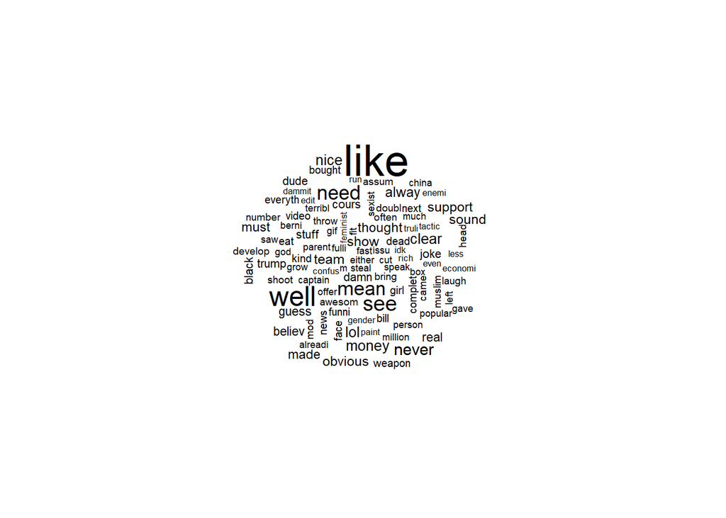

```r
cloud(stmodel_add, topic = 2, scale = c(2.5,.5))
```

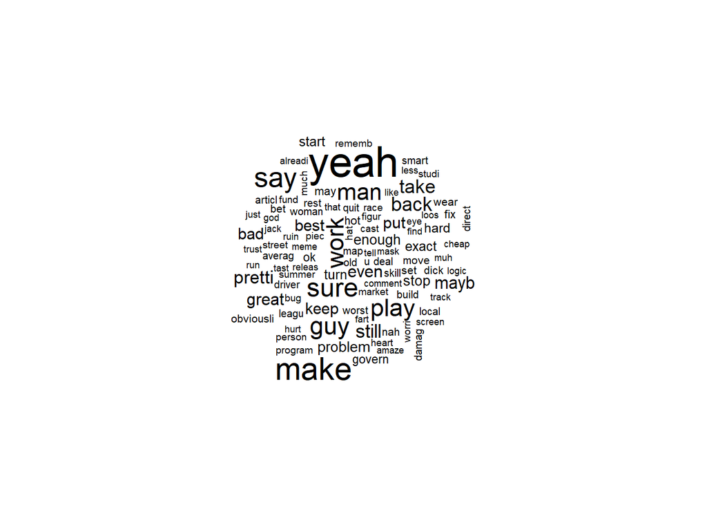

```r
cloud(stmodel_add, topic = 3, scale = c(2.5,.5))
```

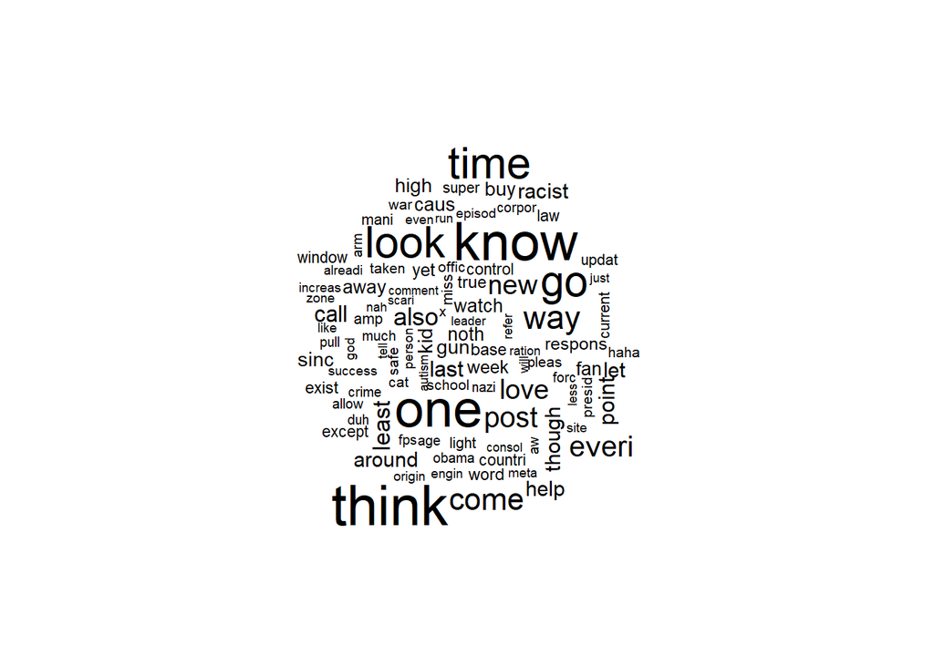

```r
cloud(stmodel_add, topic = 4, scale = c(2.5,.5))
```

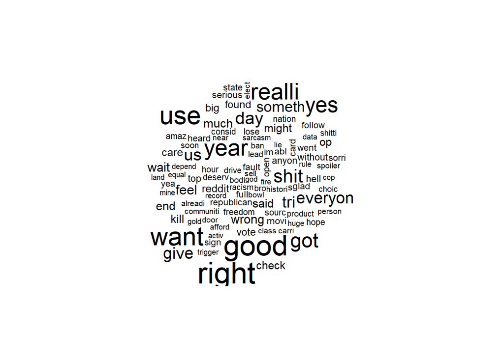

```r
cloud(stmodel_add, topic = 5, scale = c(2.5,.5))
```

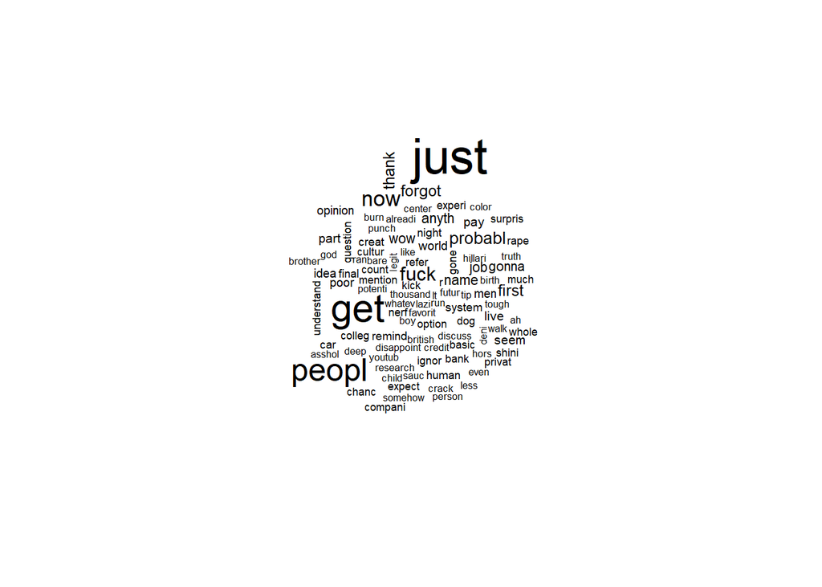

```r
cloud(stmodel_add, topic = 6, scale = c(2.5,.5))
```

```r
effect_estimates <- estimateEffect(1:6 ~ label_f, stmodel_add, meta = stm_input$meta)
```

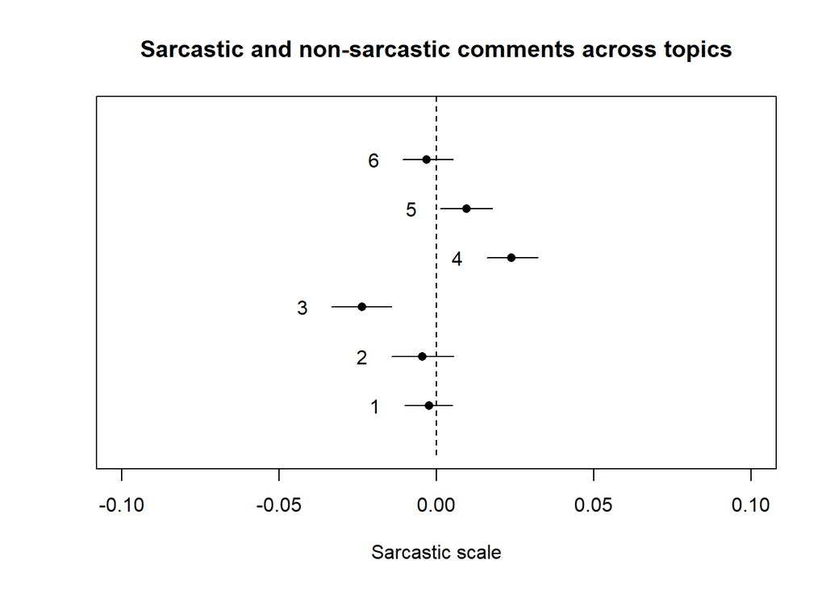

```r
plot(effect_estimates, covariate = "label_f", topics = c(1, 2, 3, 4,5,6),
     model = stmodel_add, method = "difference",
     cov.value1 = "1", cov.value2 = "0",
     xlab = "Sarcastic scale",
     main = "Sarcastic and non-sarcastic comments across topics",
     xlim = c(-.1, .1), labeltype = "custom",
     #custom.labels = c("Topic1", "Topic2")
     )
```

#LDA Deleting rows with zero observations and sorting the columns of the final dfm:

```r
sarc_dfm_nz <- sarc_dfm_noprop[rowSums(sarc_dfm_noprop) > 0,]

sarc_dfm_nz <- sarc_dfm_nz[,sort(featnames(sarc_dfm_nz))]
```

Important: Deleting the associated rows also from the main dataframe, such that we can more easily go back and forth between dataframe and dfm later:

```r
sarc_df_nz <- sarc_df[as.numeric(str_replace(rownames(sarc_dfm_nz), pattern = "text", replace = "")),]
```

```r
K <- 6
lda <- LDA(sarc_dfm_nz, k = K,
                control = list(verbose=25L, seed = 123))
```

```
## final e step document 3735
```

Look at the words most associated with each topic for a sample of topics. Put labels (on some) of the topics?

```r
top_terms <- terms(lda, 20)
top_terms
```

```
##       Topic 1  Topic 2  Topic 3  Topic 4   Topic 5  Topic 6
##  [1,] "see"    "look"   "peopl"  "get"     "just"   "like"
##  [2,] "know"   "think"  "just"   "peopl"   "like"   "well"
##  [3,] "guy"    "fuck"   "yeah"   "yeah"    "can"    "just"
##  [4,] "well"   "thing"  "can"    "time"    "better" "right"
##  [5,] "want"   "just"   "one"    "just"    "know"   "go"
##  [6,] "need"   "good"   "good"   "make"    "game"   "can"
##  [7,] "just"   "way"    "game"   "even"    "everi"  "man"
##  [8,] "like"   "forgot" "right"  "one"     "got"    "think"
##  [9,] "better" "time"   "like"   "fuck"    "now"    "say"
## [10,] "yeah"   "go"     "see"    "go"      "want"   "game"
## [11,] "come"   "now"    "work"   "think"   "use"    "now"
## [12,] "use"    "thank"  "make"   "thing"   "much"   "one"
## [13,] "level"  "come"   "thank"  "better"  "make"   "oh"
## [14,] "mean"   "yeah"   "realli" "less"    "good"   "sure"
## [15,] "year"   "call"   "say"    "well"    "yeah"   "want"
## [16,] "say"    "money"  "mean"   "happen"  "yes"    "much"
## [17,] "realli" "still"  "someon" "right"   "new"    "year"
## [18,] "look"   "yes"    "keep"   "yes"     "one"    "wrong"
## [19,] "alway"  "make"   "year"   "actual"  "ever"   "realli"
## [20,] "never"  "lol"    "reason" "everyon" "go"     "pretti"
```

Obtain the topic with the highest proportion for each of the comments. For topic 1 and 2 , sample 5 comments randomly that are predicted to contain that topic in highest proportion, and show that their semantic content (largely) reflects the topic you expected.

```r
# Topic 1
cat("\n\n Topic 1, sarcastic comments: \n")
```

```
##
##
##  Topic 1, sarcastic comments:
```

```r
top_topics <- topics(lda, 1)
set.seed(123)
sample(sarc_df_nz$comment[top_topics == 1 & sarc_df_nz$label==1], 5)
```

```
## [1] "Needs more james"
## [2] "For the children"
## [3] "What an appropriate comment in the appropriate thread."
## [4] "You have really deep thoughts."
## [5] "by proper disposal they mean reuse the same pill."
```

```r
cat("\n\n Topic 1, non-sarcastic comments: \n")
```

```
##
##
##  Topic 1, non-sarcastic comments:
```

```r
top_topics <- topics(lda, 1)
set.seed(123)
sample(sarc_df_nz$comment[top_topics == 1 & sarc_df_nz$label==0], 5)
```

```
## [1] "Clue: the problem lies in the dysfunctional double-think of children being presented as sexual yet not being allowed to be perceived as such."
## [2] "People always complain that NA needs to be better towards new and young talent, and now that a big org does it, people mean they should have picked a more experienced player."
## [3] "you have 30 boyfriends..... i see...."
## [4] "No, it's the one that goes \"judge not lest ye be judged,\" which is an excellent message coming from the part of the bible Christians are supposed to prioritize."
## [5] "I know it probably won't happen, but I want more of them together season 2"
```

```r
cat("\n\n Topic 2, sarcastic comments: \n")
```

```
##
##
##  Topic 2, sarcastic comments:
```

```r
# Topic 2
top_topics <- topics(lda, 1)
set.seed(123)
sample(sarc_df_nz$comment[top_topics == 2 & sarc_df_nz$label==1], 5)
```

```
## [1] "Look, everyone knows that interns are human garbage and they should be glad to be paid *at all*."
## [2] "But being fat is genetic and being gay is a lifestyle choice."
## [3] "At last we've found our team identity post Roy-Oden!"
## [4] "Nah, its not a smart idea."
## [5] "Put a police officer at the finish line and watch him win"
```

```r
cat("\n\n Topic 2, non-sarcastic comments: \n")
```

```
##
##
##  Topic 2, non-sarcastic comments:
```

```r
# Topic 2
top_topics <- topics(lda, 1)
set.seed(123)
sample(sarc_df_nz$comment[top_topics == 2 & sarc_df_nz$label==0], 5)
```

```
## [1] "You're gold and playing in groups."
## [2] "Kinda like when they showed DMX a computer."
## [3] "Throw in Exodia, you'll draw all 5 cards eventually."
## [4] "Some say that our plasma even disperses naturally in vacuum or atmosphere!"
## [5] "And also reminds the teacher that she forgot to collect everyones homework from yesterday right before class is over...God dammit, bitch, i forgot to do it and could have used that extra night!"
```

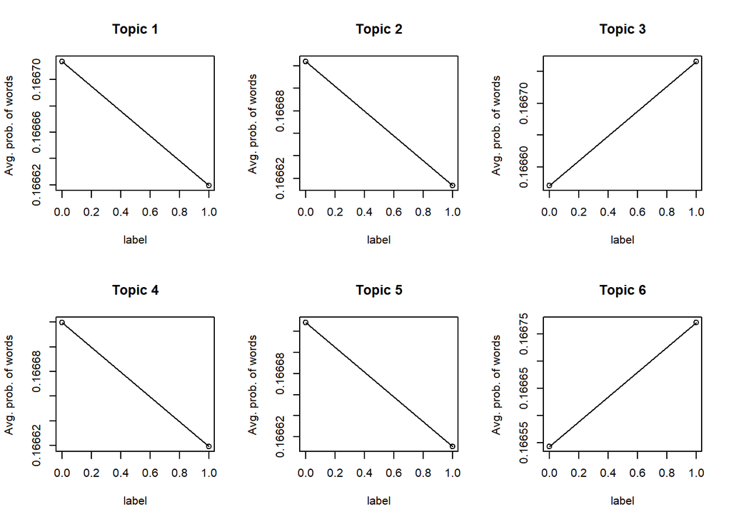

```r
#Estimated proportion of sarcastic comments on topics
# Topic 1
posterior_topic <- posterior(lda)
beta_matrix <- posterior_topic[["terms"]]
theta_matrix <- posterior_topic[["topics"]]

par(mfrow=c(2,3))
# Add probability to df
sarc_df_nz$prob_topic <- theta_matrix[, 1]

# Now aggregate at the month level
agg <- aggregate(prob_topic~label, data=sarc_df_nz, FUN=mean)

label =c(0,1)
# And plot it
plot(label, agg$prob_topic, type="o",
     xlab="label", ylab="Avg. prob. of words ",
     main="Topic 1")

#Topic 2
# Add probability to df
sarc_df_nz$prob_topic <- theta_matrix[, 2]

# Now aggregate at the month level
agg <- aggregate(prob_topic~label, data=sarc_df_nz, FUN=mean)

label =c(0,1)
# And plot it
plot(label, agg$prob_topic, type="o",
     xlab="label", ylab="Avg. prob. of words",
     main="Topic 2")

#Topic 3
# Add probability to df
sarc_df_nz$prob_topic <- theta_matrix[, 3]

# Now aggregate at the month level
agg <- aggregate(prob_topic~label, data=sarc_df_nz, FUN=mean)

label =c(0,1)
# And plot it
plot(label, agg$prob_topic, type="o",
     xlab="label", ylab="Avg. prob. of words ",
     main="Topic 3")


#Topic 4
# Add probability to df
sarc_df_nz$prob_topic <- theta_matrix[, 4]

# Now aggregate at the month level
agg <- aggregate(prob_topic~label, data=sarc_df_nz, FUN=mean)

label =c(0,1)
# And plot it
plot(label, agg$prob_topic, type="o",
     xlab="label", ylab="Avg. prob. of words",
     main="Topic 4")

#Topic 5
# Add probability to df
sarc_df_nz$prob_topic <- theta_matrix[, 5]

# Now aggregate at the month level
agg <- aggregate(prob_topic~label, data=sarc_df_nz, FUN=mean)

label =c(0,1)
# And plot it
plot(label, agg$prob_topic, type="o",
     xlab="label", ylab="Avg. prob. of words",
     main="Topic 5")


#Topic 6
# Add probability to df
sarc_df_nz$prob_topic <- theta_matrix[, 6]

# Now aggregate at the month level
agg <- aggregate(prob_topic~label, data=sarc_df_nz, FUN=mean)

label =c(0,1)
# And plot it
plot(label, agg$prob_topic, type="o",
     xlab="label", ylab="Avg. prob. of words",
     main="Topic 6")
```

For the topic 1 , use the beta matrix to obtain the top 15 words.

```r
top_words_from_beta_matrix <- beta_matrix[1, order(beta_matrix[1,], decreasing = TRUE)][1:15]
top_words_from_beta_matrix
```

```
##         see        know         guy        well        want        need
## 0.015886472 0.015286403 0.013017803 0.010620910 0.010088805 0.009153943
##        just        like      better        yeah        come         use
## 0.008743757 0.008474765 0.008183077 0.007982253 0.007211464 0.006917847
##       level        mean        year
## 0.006837408 0.006738000 0.006389949
```

```r
# The same output from before
paste(top_terms[,1], collapse=", ")
```

```
## [1] "see, know, guy, well, want, need, just, like, better, yeah, come, use, level, mean, year, say, realli, look, alway, never"
```

With the beta matrix, I the share of the word “yeah” in each of the topics.

```r
# Finding the probability of the term "trade" in each of the topics
probs <- beta_matrix[,lda@terms=="yeah"]
# Normalizing so that probabilities add up to 1
probs <- round(as.numeric(probs/sum(probs)),4)
probs
```

```
## [1] 0.1439 0.1042 0.3262 0.2327 0.1290 0.0640
```